# Potential changes of macrophyte species richness

Anne Lewerentz, Markus Hoffmann, Juliano S. Cabral et al

2022-05-27

# 1 Methods and Setup

## 1.1 Load Packages

```r
library(LewerentzEtAl2022)
library(data.table)
library(here)
library(tidyverse)
library(styler)
library(corrplot)
library(RColorBrewer)
library(ggrepel)
library(ggpmisc)
library(ggpubr)
library(kableExtra)
library(knitr)
library(BBmisc) #normalize function
library(factoextra) #PCA
library(magrittr)

# GLM outputs
library(sjPlot)
library(sjmisc)
library(sjlabelled)
library(jtools)
library(patchwork) # combine figures
library(colorBlindness) # check colors
library(rcartocolor)
```

## 1.2 Set theme & colors

```r
theme_analysis <- function(base_size = 14) {
  theme_minimal(base_size = base_size) %+replace%
    theme(
      # changed theme options
    )
}
# Changing the default theme
theme_set(theme_analysis())


# SET COLOR SCHEMES
scale_colour_continuous <- scale_colour_viridis_c
scale_colour_discrete   <- scale_colour_viridis_d
scale_colour_binned     <- scale_colour_viridis_b

# See options within package
#display_carto_all(colorblind_friendly = TRUE)

depthPalette <- carto_pal(5, "Teal")[2:5]
TempPalette<- carto_pal(3, "Peach")
TurbNutrPalette<- carto_pal(7, "Earth")[c(1:4)]
WinnerLoserPalette<- c(carto_pal(2,"PinkYl")[c(2)],carto_pal(2,"TealGrn")[c(1)])
#TrophiePalette <- c(carto_pal(4, "BrwnYl"))[-1] #oligo, meso, eu, others
TrophiePalette <- c("cornflowerblue","aquamarine4","coral4")
#displayAllColors(TrophiePalette)

#displayAllColors(depthPalette) +
  #displayAllColors(TempPalette) +
  #displayAllColors(TurbNutrPalette) +
  #displayAllColors(WinnerLoserPalette)+
  displayAllColors(TrophiePalette)
```

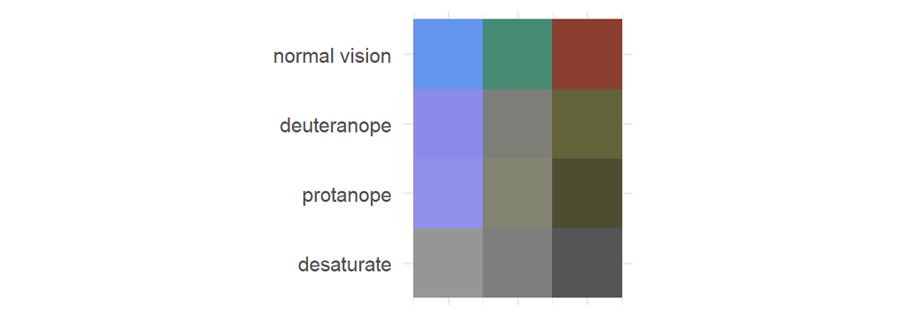

```r
# SPlength <- length(Makroph_commLastYear)-3
# Makroph_commLastYear$GAMMA <- vegan::specnumber(Makroph_commLastYear[,c(4:85)])
#
# Makroph_commLastYearfin<-Makroph_commLastYear %>% # %>%
#   filter(!Lake %in% c("Altmuehlsee", "Drachensee", "Eixendorfer See",
#                      "Grosser Brombachsee",
#                      "Gruentensee","Igelsbachsee",
#                      "Kleiner Brombachsee",
#                      "Liebensteinspeicher","Rottachsee",
#                      "Steinberger See","Untreusee",
#                      "Walchensee","Murnersee","Rothsee",
#                      "Seehamer See"))%>%
#   select(where(~ any(. != 0)))
#
# MAK_MAPPED_NSPEC <- Makroph_commLastYearfin %>%
#   select(-Lake, -YEAR, -Depth, -GAMMA) %>% ncol()
#
# MAK_MAPPED<-Makroph_commLastYearfin %>%
#   #rename(Lake=Gewässer, Depth=Tiefe) %>% #%>%  spread(Depth, GAMMA)
#   select(Lake, YEAR, Depth, GAMMA) %>%
#   mutate(GAMMAperc = GAMMA/MAK_MAPPED_NSPEC*100)
#
# MAK_MAPPED$LakeID <- MAK_MAPPED  %>% group_indices(Lake)
#
# MAK_MAPPED <- MAK_MAPPED %>% mutate(LakeID=paste0("lake_",LakeID))
#
# fulllakenames <- MAK_MAPPED %>% select(Lake,LakeID) %>% unique() %>%
#   filter(LakeID!="lake_11")
#
# MAK_MAPPED_di<-Makroph_commLastYearfin %>%
#   group_by(Lake) %>%
#   summarise_at(vars(Callitriche.cophocarpa:Zannichellia.palustris), mean, na.rm = TRUE)
#
# MAK_MAPPED_di$GAMMA <- vegan::specnumber(MAK_MAPPED_di[,c(2:72)])
#
# MAK_MAPPED_din<-MAK_MAPPED_di %>%
#   select(Lake,GAMMA)%>%
#   mutate(GAMMAperc = GAMMA/MAK_MAPPED_NSPEC*100)
#
#
# MAK_MAPPED_din$LakeID <- MAK_MAPPED_din  %>% group_indices(Lake)
#
# MAK_MAPPED_din <- MAK_MAPPED_din %>% mutate(LakeID=paste0("lake_",LakeID))
```

Mean lake area per lake group

```r
data_lakes_env_class %>%
  left_join(Morphology, by=c("LakeName"="Name_Makro_short") ) %>%
  group_by(class) %>%
  summarise(Area_mean_ha=mean(Area_ha),
            maxDepth_mean_m=mean(maxDepth_m),
            Altitude_mean_masl=mean(Altitude_masl),
            CatchArea_mean_km2=mean(CatchmentArea_km2))
```

```
## # A tibble: 3 x 5
##   class  Area_mean_ha maxDepth_mean_m Altitude_mean_masl CatchArea_mean_km2
##   <chr>         <dbl>           <dbl>              <dbl>              <dbl>
## 1 clear          282.            56.4               747.              128.
## 2 medium        1462.            41.5               603.              210.
## 3 turb           333.            20.2               530.               55.5
```

Number of Lakes per Lake group

```r
data_lakes_env_class %>% count(class) %>% kable() %>% kable_styling()
```

| class | n |
| --- | --- |
| clear | 10 |
| medium | 15 |
| turb | 5 |

# 2 Results

## 2.1 Env conditions within scenarios

```r
data_lakes_env_classfuture<-data_lakes_env_class

data_lakes_env_classfuture$maxNut_m1 <- data_lakes_env_classfuture$maxNutrient-0.25*data_lakes_env_classfuture$maxNutrient

data_lakes_env_classfuture$maxNut_1 <- data_lakes_env_classfuture$maxNutrient+0.25*data_lakes_env_classfuture$maxNutrient

data_lakes_env_classfuture$maxkD_m1 <- data_lakes_env_classfuture$maxKd-0.25*data_lakes_env_classfuture$maxKd

data_lakes_env_classfuture$maxkD_1 <- data_lakes_env_classfuture$maxKd+0.25*data_lakes_env_classfuture$maxKd

data_lakes_env_classfuture$maxTemp_1 <- data_lakes_env_classfuture$maxTemp+1.5

data_lakes_env_classfuture$maxTemp_2 <- data_lakes_env_classfuture$maxTemp+3.0

meanEnv<-data_lakes_env_classfuture %>% group_by(class) %>%
  select(latitude, maxNutrient, maxTemp, maxKd) %>%
  summarise_each(funs(mean, sd))

knitr::kable(meanEnv[,c(1:5)], digits = 4)
```

| class | latitude_mean | maxNutrient_mean | maxTemp_mean | maxKd_mean |
| --- | --- | --- | --- | --- |
| clear | 47.5631 | 0.0069 | 20.9700 | 0.2740 |
| medium | 47.8144 | 0.0117 | 24.3667 | 0.3953 |
| turb | 47.8574 | 0.0292 | 25.0600 | 0.6340 |

```r
knitr::kable(meanEnv[,c(1,6:9)], digits = 4)
```

| class | latitude_sd | maxNutrient_sd | maxTemp_sd | maxKd_sd |
| --- | --- | --- | --- | --- |
| clear | 0.0970 | 0.0031 | 1.8750 | 0.1408 |
| medium | 0.1507 | 0.0040 | 1.0682 | 0.1046 |
| turb | 0.1233 | 0.0091 | 2.6378 | 0.1942 |

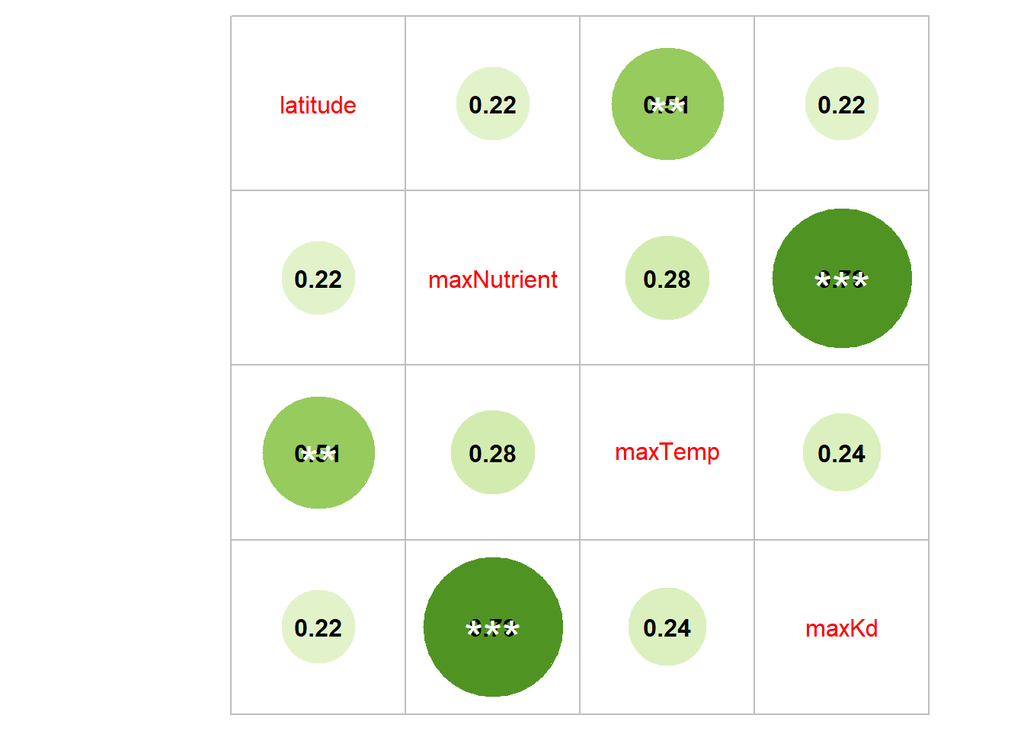

```r
env_table<-data_lakes_env_classfuture %>% group_by(class) %>%
  select(latitude, maxNutrient, maxTemp, maxKd)




M = cor(env_table %>% ungroup() %>%
          select(latitude, maxNutrient,maxTemp,maxKd))
res1 <- cor.mtest(env_table %>% ungroup() %>%
          select(latitude, maxNutrient,maxTemp,maxKd), conf.level = .95)
corrplot(M, #order = 'AOE',
         addCoef.col = 'black', tl.pos = 'd',
         cl.pos = 'n', col = COL2('PiYG'),p.mat = res1$p, #sig.level = .2,
         insig = "label_sig",
         sig.level = c(.001, .01, .05), pch.cex=2, pch.col = "white")
```

## 2.2 Q1 - Pot. species richness

### 2.2.1 All together: N of species

```r
surv_spec <- data %>%
  filter(Biomass_cat != 0) %>%
  distinct(Species)

NSPECtotal <- data %>% select(specNr) %>% unique() %>% count()
NLAKEStotal <- data %>% select(lakeNr) %>% unique() %>% count()

NSPECbase <- dim(surv_spec)[[1]]
```

In total, 540 species out of 900 can grow in 30 real lakes. These 540 will be called as 100%.

```r
Tv1<-data %>%
  #filter(Biomass_cat != 0) %>%
  group_by(Group) %>%
  distinct(Species) %>% count(Group)

Tv2<-data %>%
  #filter(Biomass_cat != 0) %>%
  group_by(Biomass_cat,Group) %>%
  distinct(Species) %>% count(Group) %>%
  spread("Biomass_cat","n") %>%
  rename("growing"="1")

d1nsp<-data %>%
  filter(depth_1 != 0) %>%
  group_by(Group) %>%
  distinct(Species) %>%
  count(Group) %>%
  rename("depth_1"="n")

d2nsp<-data %>%
  filter(depth_2 != 0) %>%
  group_by(Group) %>%
  distinct(Species) %>%
  count(Group) %>%
  rename("depth_2"="n")
d3nsp<-data %>%
  filter(depth_3 != 0) %>%
  group_by(Group) %>%
  distinct(Species) %>%
  count(Group) %>%
  rename("depth_3"="n")
d4nsp<-data %>%
  filter(depth_4 != 0) %>%
  group_by(Group) %>%
  distinct(Species) %>%
  count(Group) %>%
  rename("depth_4"="n")

NSpGroups<-left_join(Tv1, Tv2, by="Group") %>%
  rename("space"="n") %>% select(-`0`) %>%
  left_join(d1nsp,by="Group") %>% left_join(d2nsp,by="Group") %>%
  left_join(d3nsp,by="Group")%>% left_join(d4nsp,by="Group") %>%
  mutate(growing_P=(growing/NSPECbase)*100)%>%
  mutate(depth_1_P=(depth_1/NSPECbase)*100)%>%
  mutate(depth_2_P=(depth_2/NSPECbase)*100)%>%
  mutate(depth_3_P=(depth_3/NSPECbase)*100)%>%
  mutate(depth_4_P=(depth_4/NSPECbase)*100)%>%
  select(-depth_1,-depth_2,-depth_3,-depth_4)

knitr::kable(NSpGroups, digits = 1)
```

| Group | space | growing | growing_P | depth_1_P | depth_2_P | depth_3_P | depth_4_P |
| --- | --- | --- | --- | --- | --- | --- | --- |
| eutroph | 300 | 200 | 37.0 | 20.6 | 35.4 | 32.0 | 25.2 |
| mesotroph | 300 | 186 | 34.4 | 17.4 | 32.8 | 28.5 | 24.3 |
| oligotroph | 300 | 154 | 28.5 | 14.6 | 26.1 | 24.1 | 17.2 |

Thus, it’s a hump-shaped pattern of possible species richness of submerged macrophytes.

How does that look like for real species

```r
knitr::kable(MAK_grouped_depthindep_alllakes, digits = 1)
```

| Group | NSPEC | NSPECperc |
| --- | --- | --- |
| 1 | 4 | 11.4 |
| 2 | 19 | 54.3 |
| 3 | 12 | 34.3 |
| none | 25 | 71.4 |

Complete N of species within the mapped datasets, just indicator species 35

### 2.2.2 Per lake: N of species

```r
richLake<-data %>%
  group_by(Lake) %>%
  summarise_at(vars(Biomass_cat), ~ sum(. != 0)) %>%
  arrange(Biomass_cat) %>% # depth_1,depth_2,depth_3,depth_4,
  rename("Nspecies" = Biomass_cat) %>%
  filter(Nspecies==max(Nspecies))

richLakeName <- MAK_MAPPED %>% filter(LakeID==richLake$Lake) %>% select(Lake) %>% unique()

poorLake<-data %>%
  group_by(Lake) %>%
  summarise_at(vars(Biomass_cat), ~ sum(. != 0)) %>%
  arrange(Biomass_cat) %>% # depth_1,depth_2,depth_3,depth_4,
  rename("Nspecies" = Biomass_cat) %>%
  filter(Nspecies==min(Nspecies))

poorLakeName <- MAK_MAPPED %>% filter(LakeID==poorLake$Lake) %>% select(Lake) %>% unique()
```

Per lake between 24 (lake_5 in Barmsee, - 4.44 %) and 514 (lake_15 in Langbuergner See, - 95.19 %) species can grow.

Thus, we have a difference between lakes.

```r
real_Barmsee <-MAK_grouped_depthindep %>% filter(Lake=="Barmsee") %>%
  filter(Group!="none") %>% ungroup() %>% summarise(NSPECperc=sum(NSPECperc))
```

Realised species richness Barmsee: 5.7142857

```r
real_Langbuerg<-MAK_grouped_depthindep %>% filter(Lake=="Langbuergner See") %>%
  filter(Group!="none") %>% ungroup() %>% summarise(NSPECperc=sum(NSPECperc))
```

Real. spec richness Langbürgner See: 34.2857143

### 2.2.3 Per lakes group

Potential

```r
Nspecies_P_groupes<-data %>%
  left_join((data_lakes_env_class %>%
               select(Lake, class)%>%
               mutate(Lake=paste0("lake_",Lake))),
            by=c("Lake"))%>%
  group_by(class, specNr, Group) %>%
  summarise_at(vars(Biomass_cat), ~ sum(. != 0)) %>%
  mutate(Biomass_cat=ifelse(Biomass_cat>0,1,0))%>%

  ungroup() %>% group_by(class, Group) %>%
  summarise(Biomass_cat=sum(Biomass_cat)) %>%
  rename("Nspecies" = Biomass_cat) %>%
  mutate(Nspecies_P = (Nspecies/NSPECbase)*100) %>%
  select(-Nspecies) %>%
  spread(Group, Nspecies_P)

Nspecies_P_groupes_all<-data %>%
  left_join((data_lakes_env_class %>%
               select(Lake, class)%>%
               mutate(Lake=paste0("lake_",Lake))),
            by=c("Lake"))%>%

  group_by(class, specNr) %>%
  summarise_at(vars(Biomass_cat), ~ sum(. != 0)) %>%
  mutate(Biomass_cat=ifelse(Biomass_cat>0,1,0))%>%

  ungroup() %>% group_by(class) %>%
  summarise(Biomass_cat=sum(Biomass_cat)) %>%
  rename("Nspecies" = Biomass_cat) %>%
  mutate(Nspecies_P_all = (Nspecies/NSPECbase)*100) %>%
  select(-Nspecies)

knitr::kable(left_join(Nspecies_P_groupes,Nspecies_P_groupes_all, by="class"), digits = 1)
```

| class | eutroph | mesotroph | oligotroph | Nspecies_P_all |
| --- | --- | --- | --- | --- |
| clear | 30.0 | 28.0 | 21.3 | 79.3 |
| medium | 35.9 | 34.1 | 28.5 | 98.5 |
| turb | 36.9 | 33.0 | 24.3 | 94.1 |

Realised % of species within lake groups and per species groups

```r
Nspaclakclass<-Makroph_comm_S %>%
  gather("Species", "Kohler",5:89) %>%
  mutate(Species = str_replace(Species, " ", "."))%>%
  left_join(GroupsSpecies, by = c("Species"="Taxon")) %>%
  select(-Trophie,-Typ, -Depth) %>%
  mutate(Gruppe = ifelse(is.na(Gruppe),"none", Gruppe)) %>%
  filter(!Lake %in% c("Altmuehlsee", "Drachensee", "Eixendorfer See",
                      "Grosser Brombachsee",
                     "Gruentensee","Igelsbachsee", "Kleiner Brombachsee",
                     "Liebensteinspeicher","Rottachsee",
                     "Steinberger See","Hofstaetter See",
                     "Untreusee","Walchensee","Murnersee","Rothsee",
                     "Seehamer See"))%>%
  rename(Group=Gruppe)%>%
  ungroup() %>%
  group_by(Lake) %>%
  filter(YEAR==max(YEAR))%>% #select last mapping per lake
  ungroup() %>%
  left_join(data_lakes_env_class, by=c("Lake"="LakeName")) %>%
  rename(LakeID=Lake.y) %>%


  group_by(Species, Group, class) %>%
  summarise_at(vars("Kohler"), sum, na.rm=T)%>% # Mean of Kohler per Lake, YEAR, Depth, Species and Group
  ungroup()%>%
  group_by(Group, class) %>%
  mutate(Kohler=ifelse(Kohler>0,1,0)) %>%
  summarise(NSPEC=sum(Kohler)) %>%
  mutate(NSPECperc = NSPEC/MAK_MAPPED_NSPEC_indicationspec$n*100) %>%
  select(-NSPEC)%>%
  spread(Group,NSPECperc)%>%
  rename(oligotrophic="1", mesotrophic="2", eutrophic="3")


Nspaclakclass_all<-Makroph_comm_S %>%
  gather("Species", "Kohler",5:89)%>%
  mutate(Species = str_replace(Species, " ", ".")) %>%
  left_join(GroupsSpecies, by = c("Species"="Taxon")) %>%
  select(-Trophie,-Typ, -Depth) %>%
  mutate(Gruppe = ifelse(is.na(Gruppe),"none", Gruppe)) %>%
  filter(!Lake %in% c("Altmuehlsee", "Drachensee", "Eixendorfer See",
                      "Grosser Brombachsee",
                     "Gruentensee","Igelsbachsee", "Kleiner Brombachsee",
                     "Liebensteinspeicher","Rottachsee",
                     "Steinberger See","Hofstaetter See",
                     "Untreusee","Walchensee","Murnersee","Rothsee",
                     "Seehamer See"))%>%
  rename(Group=Gruppe)%>%
  ungroup() %>%
  group_by(Lake) %>%
  filter(YEAR==max(YEAR))%>% #select last mapping per lake
  ungroup() %>%
  left_join(data_lakes_env_class, by=c("Lake"="LakeName")) %>%
  rename(LakeID=Lake.y) %>%
  filter(Group!="none")%>%

  group_by(Species, class) %>%
  summarise_at(vars("Kohler"), sum, na.rm=T)%>% # Mean of Kohler per Lake, YEAR, Depth, Species and Group
  ungroup()%>%
  group_by(class) %>%
  mutate(Kohler=ifelse(Kohler>0,1,0)) %>%
  summarise(NSPEC=sum(Kohler)) %>%
  mutate(NSPECperc_all = NSPEC/MAK_MAPPED_NSPEC_indicationspec$n*100) %>%
  select(-NSPEC)

knitr::kable(left_join(Nspaclakclass, Nspaclakclass_all, by="class"), digits = 1)
```

| class | oligotrophic | mesotrophic | eutrophic | none | NSPECperc_all |
| --- | --- | --- | --- | --- | --- |
| clear | 11.4 | 45.7 | 25.7 | 31.4 | 82.9 |
| medium | 5.7 | 48.6 | 34.3 | 68.6 | 88.6 |
| turb | 0.0 | 25.7 | 22.9 | 14.3 | 48.6 |

### 2.2.4 Chi square test

```r
#Observed vrs potential
OSRPSR<-left_join(Nspaclakclass, Nspecies_P_groupes, by="class") %>% select(-none)
samp<-as.data.frame(OSRPSR)
samp2 <- samp[,-1]
rownames(samp2) <- samp[,1]


olig<-samp2[c(1,6)]
chi<-chisq.test(olig)
chi
```

```
##
##  Pearson's Chi-squared test
##
## data:  olig
## X-squared = 11.292, df = 2, p-value = 0.003532
```

```r
mesot<-samp2[c(2,5)]
chim<-chisq.test(mesot)
chim
```

```
##
##  Pearson's Chi-squared test
##
## data:  mesot
## X-squared = 4.8744, df = 2, p-value = 0.08741
```

```r
eutro<-samp2[c(3,4)]
chie<-chisq.test(eutro)
chie
```

```
##
##  Pearson's Chi-squared test
##
## data:  eutro
## X-squared = 1.528, df = 2, p-value = 0.4658
```

```r
samp3<- as.data.frame(left_join(Nspaclakclass_all,Nspecies_P_groupes_all, by="class"))
 samp4 <- samp3[,-1]
rownames(samp4) <- samp3[,1]
 chiall<-chisq.test(samp4)
chiall
```

```
##
##  Pearson's Chi-squared test
##
## data:  samp4
## X-squared = 9.7659, df = 2, p-value = 0.007575
```

### 2.2.5 FIG2 : DDG

```r
lakesDDGModel<-data %>%
  group_by(Lake, Group) %>%
  summarise_at(vars(depth_1, depth_2, depth_3, depth_4), ~ sum(. != 0)) %>%
  gather("depth", "NSpec", c(3:6))%>%
  mutate(NSpecP=(NSpec/NSPECbase)*100) %>%
  select(-NSpec) %>%
  mutate(type="model")

lakesDDGMapped <- MAK_mapped_grouped %>%
  mutate(depth=ifelse(Depth==-5.0, "depth_4",
                      ifelse(Depth==-3.0, "depth_3",
                             ifelse(Depth==-1.5, "depth_2",
                                    ifelse(Depth==-0.5, "depth_1",NA))))) %>%
  mutate(type="mapped") %>%
  rename(NSpecP=NSPECperc) %>%
  ungroup() %>%
  select(-NSPEC, -Depth, -Lake) %>%
  relocate(depth, .after = Group) %>%
  relocate(LakeID, .before = Group) %>%
  rename(Lake=LakeID) %>%
  filter(Group!="none")%>%
  mutate(Group=ifelse(Group==1, "oligotroph",
                      ifelse(Group==2, "mesotroph",
                             ifelse(Group==3, "eutroph", NA))))

lakesDDG2 = rbind(lakesDDGModel,lakesDDGMapped)

lakesDDG = lakesDDG2 %>%
  left_join(fulllakenames, by=c("Lake"="LakeID")) %>%
  rename(LakeName = Lake.y) %>%
  mutate(depth=ifelse(depth=="depth_1","-0.5",
                      ifelse(depth=="depth_2","-1.5",
                             ifelse(depth=="depth_3","-3.0",
                                    ifelse(depth=="depth_4","-5.0","NA"))))) %>%
  mutate(Group=ifelse(Group=="eutroph","eutraphentic",
                      ifelse(Group=="mesotroph","mesotraphentic",
                             ifelse(Group=="oligotroph","oligotraphentic","NA"))))
```

```r
my.formula <- y ~ x

lakeclasses<-c("clear lakes","intermediate lakes", "turbid lakes")
names(lakeclasses)<-c("clear","medium","turb")


A1<-lakesDDG %>%
  filter(type=="model")%>%
  left_join((data_lakes_env_class %>% mutate(Lake=paste0("lake_",Lake)) %>%
               select(-LakeName)),
            by=c("Lake"))%>%
  ggplot(aes(depth, NSpecP, col=Group, group=interaction(Group,Lake)))+
  geom_path(alpha=0.5)+
  geom_boxplot(aes(group=interaction(depth,Group), fill=Group))+
  facet_grid(~class,
              labeller = labeller(class = lakeclasses))+
  scale_colour_manual(values = c(rev(TrophiePalette)))+
  theme(legend.title = element_blank()) +
  xlab("Depth (m)")+
  theme(axis.text.x = element_text(angle = 90, vjust = 0.5, hjust=1))+
  theme(legend.position = "none")+
  #ggtitle("Potential species richness (model)")+
  ylab("")+
  scale_fill_manual(values = c(rev(TrophiePalette)))+
  ylab("Potential \nspec. richness (%)")

A2<-lakesDDG %>%
  filter(type=="mapped")%>%
  left_join((data_lakes_env_class %>% mutate(Lake=paste0("lake_",Lake)) %>%
               select(-LakeName)),
            by=c("Lake"))%>%
  ggplot(aes(depth, NSpecP, col=Group, group=interaction(Group,Lake)))+
  geom_path(alpha=0.5)+
  geom_boxplot(aes(group=interaction(depth,Group), fill=Group))+
  facet_grid(~class,
              labeller = labeller(class = lakeclasses))+
  scale_colour_manual(values = c(rev(TrophiePalette)))+
  theme(legend.title = element_blank()) +
  xlab("Depth (m)")+
  theme(axis.text.x = element_text(angle = 90, vjust = 0.5, hjust=1))+
  theme(legend.position = "none")+
  #ggtitle("Realised species richness (mapped)")+
  scale_fill_manual(values = c(rev(TrophiePalette)))+
  ylab("Observed \nspec. richness (%)")


A3<-lakesDDG %>%
  #filter(type=="mapped")%>%
  left_join((data_lakes_env_class %>% mutate(Lake=paste0("lake_",Lake)) %>%
               select(-LakeName)),
            by=c("Lake")) %>%
  spread(type,NSpecP) %>%
  ggplot(aes(x=model,y=mapped, col=Group))+
  geom_point()+
  facet_grid(~class,
              labeller = labeller(class = lakeclasses))+ #aes(col=Name)
  #geom_smooth(model=lm, method=lm, se=F, formula = my.formula,
  #            #aes(group=factor(depth), col=factor(depth))
  #            )+
  stat_correlation(vstep = 0.1,label.x = "centre")+
  #stat_poly_eq(formula = my.formula,
  #              eq.with.lhs = "italic(hat(y))~`=`~",
  #              aes(label = paste(..rr.label.., sep = "~~~")))+
  scale_colour_manual(values = c(rev(TrophiePalette)))+
  #ggtitle("comparison")+
  geom_abline(intercept = 0, slope = 1)+
  #annotate("text", x = 22, y = 25, label = "model = mapped", angle=34)+
  xlab("Potential spec. richness (%)")+
  ylab("Observed \nspec. richness (%)")+
  ylim(0,40)+xlim(0,40)
```

##### 2.2.5.0.1 Fig2 plot

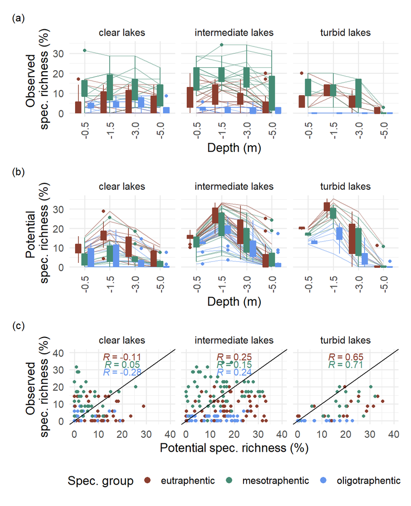

```r
FIG2<-((A2/A1) / A3) +theme(legend.position = "bottom")+
  labs(col="Spec. group") +
  plot_annotation(tag_levels = 'a',
                  tag_prefix = '(',
                  tag_suffix = ')')&
  theme(plot.tag = element_text(size = 12))&
  guides(colour = guide_legend(override.aes = list(size=3)))

FIG2
```

```r
#ggsave("Fig2.png", FIG2, width = 6.5, height=8, dpi="print", bg="white")
```

```r
lakesDDG %>%
  #filter(type=="mapped")%>%
  left_join((data_lakes_env_class %>% mutate(Lake=paste0("lake_",Lake)) %>%
               select(-LakeName)),
            by=c("Lake")) %>%
  spread(type,NSpecP)%>%
  mutate(potMINUSobserv=model-mapped)%>%
  mutate(error=ifelse(potMINUSobserv>0,"underestim",
                      ifelse(potMINUSobserv<0,"overestim",
                      "exact"))) %>%
  group_by(Group,class) %>%
  count(error)%>%
  spread("error","n")
```

```
## # A tibble: 9 x 5
## # Groups:   Group, class [9]
##   Group           class  exact overestim underestim
##   <chr>           <chr>  <int>     <int>      <int>
## 1 eutraphentic    clear     NA        11         29
## 2 eutraphentic    medium     2        11         47
## 3 eutraphentic    turb       3         4         13
## 4 mesotraphentic  clear      2        31          7
## 5 mesotraphentic  medium     2        34         24
## 6 mesotraphentic  turb       4         3         13
## 7 oligotraphentic clear      3        22         15
## 8 oligotraphentic medium     1         6         53
## 9 oligotraphentic turb       4        NA         16
```

#### 2.2.5.1 DDG for summary figure

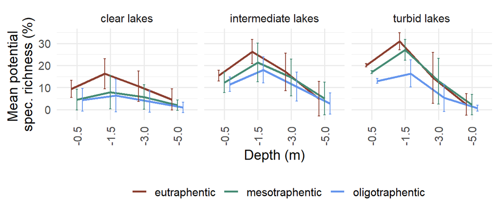

```r
Fig5_part<-lakesDDG %>%
  filter(type=="model")%>%
  left_join((data_lakes_env_class %>% mutate(Lake=paste0("lake_",Lake)) %>%
               select(-LakeName)),
            by=c("Lake"))%>%
  group_by(Group,depth,class) %>%
  summarise(NSpecPmean=mean(NSpecP),NSpecPsd=sd(NSpecP))%>%
  ggplot(aes(depth, NSpecPmean, col=Group, group=interaction(Group)))+
  #geom_boxplot(aes(group=interaction(depth,Group), fill=Group))+
  facet_grid(~class,
              labeller = labeller(class = lakeclasses))+
  geom_path(position=position_dodge(0.5), size=1)+
  geom_errorbar(aes(ymin=NSpecPmean-NSpecPsd, ymax=NSpecPmean+NSpecPsd), width=.2,
                 position=position_dodge(0.5))+

  scale_colour_manual(values = c(rev(TrophiePalette)))+
  theme(legend.title = element_blank()) +
  xlab("Depth (m)")+
  theme(axis.text.x = element_text(angle = 90, vjust = 0.5, hjust=1))+
  theme(legend.position = "bottom")+
  #ggtitle("Potential species richness (model)")+
  scale_fill_manual(values = c(rev(TrophiePalette)))+
  ylab("Mean potential \nspec. richness (%)")

Fig5_part
```

```r
#ggsave("Fig5_part.png", Fig5_part, width = 6.5, height=3, dpi="print", bg="white")
```

## 2.3 Q2 - Scenarios

### 2.3.1 All lakes together

#### 2.3.1.1 Number of lost species per scenario [%]

```r
#Berechnung überprüft

NSPECbase<-scenario_data %>% select(speciesID) %>% unique() %>% nrow()

SPEC_DEAD <- all_diff_presabs_tobase %>%
  group_by(speciesID) %>% select(-lakeID,-variable) %>%
  summarise_all(sum) %>% #Pro Art Summe aus Tiefen und Seen
  #filter(base>0) %>% #nur Arten, die schon vorkamen
  select(base,S0_m1,S0_1,S0_2,S1_m1,S1_0, S1_1,S1_2,S2_m1,S2_0,S2_1,S2_2) %>%
  summarise_all(funs(sum(. > 0, na.rm = TRUE))) %>% # N species pro Szen if present
  gather("scenario","Ntotspec",1:12) %>%
  mutate(Lost= Ntotspec - NSPECbase) %>%
  mutate(Lost_percent = (Lost/NSPECbase)*100) %>%
  filter(scenario!="base") %>%
  mutate(Temp=c(0,0,0,1,1,1,1,2,2,2,2)) %>%
  mutate(TurbN=c(-1,1,2,-1,0,1,2,-1,0,1,2)) %>%
  select(-Ntotspec,-Lost,-scenario) %>%
  spread(TurbN,Lost_percent) %>%
  rename("lostsp(%)"="Temp")

knitr::kable(SPEC_DEAD, digits = 1)%>% kable_styling()
```

| lostsp(%) | -1 | 0 | 1 | 2 |
| --- | --- | --- | --- | --- |
| 0 | -0.7 | NA | -2.0 | -4.3 |
| 1 | 0.0 | 0 | -1.3 | -3.1 |
| 2 | 0.0 | 0 | -0.7 | -2.8 |

#### 2.3.1.2 Nspec lost per trophy group

```r
NSPECbaseGroup <- scenario_data %>%
  filter(speciesID %in% c(14000:14300))%>% select(speciesID) %>% unique() %>% nrow()
SPEC_DEAD_group_oli <- all_diff_presabs_tobase %>%
  filter(speciesID %in% c(14000:14300)) %>%
  group_by(speciesID) %>% select(-lakeID,-variable) %>%
  summarise_all(sum) %>% filter(base>0) %>% select(base,S0_m1,S0_1,S0_2,
                                                   S1_m1,S1_0, S1_1,S1_2,
                                                   S2_m1,S2_0,S2_1,S2_2) %>%
    summarise_all(funs(sum(. > 0, na.rm = TRUE))) %>%
  gather("scenario","Ntotspec",1:12) %>%
  mutate(Lost= Ntotspec - NSPECbaseGroup) %>%
  mutate(Lost_percent = (Lost/NSPECbaseGroup)*100) %>%
  filter(scenario!="base") %>%
  mutate(Temp=c(0,0,0,1,1,1,1,2,2,2,2)) %>%
  mutate(TurbN=c(-1,1,2,-1,0,1,2,-1,0,1,2)) %>%
  select(-Ntotspec,-Lost,-scenario) %>%
  spread(TurbN,Lost_percent) %>%
  rename("lostspOlig(%)"="Temp")

NSPECbaseGroup <- scenario_data %>%
  filter(speciesID %in% c(15000:15300))%>% select(speciesID) %>% unique() %>% nrow()
SPEC_DEAD_group_meso <- all_diff_presabs_tobase %>%
  filter(speciesID %in% c(15001:15300)) %>%
  group_by(speciesID) %>% select(-lakeID,-variable) %>%
  summarise_all(sum) %>% filter(base>0) %>% select(base,S0_m1,S0_1,S0_2,
                                                   S1_m1,S1_0, S1_1,S1_2,
                                                   S2_m1,S2_0,S2_1,S2_2) %>%
    summarise_all(funs(sum(. > 0, na.rm = TRUE))) %>%
  gather("scenario","Ntotspec",1:12) %>%
  mutate(Lost= Ntotspec - NSPECbaseGroup) %>%
  mutate(Lost_percent = (Lost/NSPECbaseGroup)*100) %>%
  filter(scenario!="base") %>%
  mutate(Temp=c(0,0,0,1,1,1,1,2,2,2,2)) %>%
  mutate(TurbN=c(-1,1,2,-1,0,1,2,-1,0,1,2)) %>%
  select(-Ntotspec,-Lost,-scenario) %>%
  spread(TurbN,Lost_percent) %>%
  rename("lostspMeso(%)"="Temp")

NSPECbaseGroup <- scenario_data %>%
  filter(speciesID %in% c(16000:16300))%>% select(speciesID) %>% unique() %>% nrow()

SPEC_DEAD_group_eu <- all_diff_presabs_tobase %>%
  filter(speciesID %in% c(16001:16300)) %>%
  group_by(speciesID) %>% select(-lakeID,-variable) %>%
  summarise_all(sum) %>% filter(base>0) %>% select(base,S0_m1,S0_1,S0_2,
                                                   S1_m1,S1_0, S1_1,S1_2,
                                                   S2_m1,S2_0,S2_1,S2_2) %>%
    summarise_all(funs(sum(. > 0, na.rm = TRUE))) %>%
  gather("scenario","Ntotspec",1:12) %>%
  mutate(Lost= Ntotspec - NSPECbaseGroup) %>%
  mutate(Lost_percent = (Lost/NSPECbaseGroup)*100) %>%
  filter(scenario!="base") %>%
  mutate(Temp=c(0,0,0,1,1,1,1,2,2,2,2)) %>%
  mutate(TurbN=c(-1,1,2,-1,0,1,2,-1,0,1,2)) %>%
  select(-Ntotspec,-Lost,-scenario) %>%
  spread(TurbN,Lost_percent) %>%
  rename("lostspeu(%)"="Temp")

knitr::kable(SPEC_DEAD_group_oli, digits = 1)%>% kable_styling()
```

| lostspOlig(%) | -1 | 0 | 1 | 2 |
| --- | --- | --- | --- | --- |
| 0 | -0.6 | NA | -5.8 | -11.7 |
| 1 | 0.0 | 0 | -3.2 | -8.4 |
| 2 | 0.0 | 0 | -1.9 | -7.8 |

```r
knitr::kable(SPEC_DEAD_group_meso, digits = 1)%>% kable_styling()
```

| lostspMeso(%) | -1 | 0 | 1 | 2 |
| --- | --- | --- | --- | --- |
| 0 | -0.5 | NA | -1.1 | -2.7 |
| 1 | 0.0 | 0 | -1.1 | -2.2 |
| 2 | 0.0 | 0 | -0.5 | -1.6 |

```r
knitr::kable(SPEC_DEAD_group_eu, digits = 1)%>% kable_styling()
```

| lostspeu(%) | -1 | 0 | 1 | 2 |
| --- | --- | --- | --- | --- |
| 0 | -1 | NA | 0 | 0 |
| 1 | 0 | 0 | 0 | 0 |
| 2 | 0 | 0 | 0 | 0 |

s sterben unter heutigen Temperaturbedingungen mehr Arten aus, als wenn sich die Temperatur erhöht. Oligrotrophe Arten sind besonders betroffen vom Aussterben Eutrophe Arten sterben unter klareren Bedingungen nur minimal aus

#### 2.3.1.3 Per lake group

```r
all_diff_presabs_tobase %>%
  left_join((data_lakes_env_class %>%
               select(Lake, class)),
            by=c("lakeID"="Lake"))%>%
  group_by(speciesID, class) %>% select(-lakeID,-variable) %>%
  summarise_all(sum) %>% filter(base>0) %>% select(class,base,S0_m1,S0_1,S0_2,
                                                   S1_m1,S1_0, S1_1,S1_2,
                                                   S2_m1,S2_0,S2_1,S2_2) %>%
  mutate_at(vars(base,S0_m1,S0_1,S0_2,S1_m1,S1_0, S1_1,S1_2,
                 S2_m1,S2_0,S2_1,S2_2), ~ 1 * (. != 0)) %>%
  ungroup() %>% group_by(class) %>% select(-speciesID) %>%
  summarise_all(sum) %>%

  gather("scenario","Ntotspec",3:13) %>%
  mutate(Lost= Ntotspec - base) %>%
  mutate(Lost_percent = (Lost/base)*100) %>% select(-base,-Lost,-Ntotspec) %>%
  spread(class,Lost_percent) %>%
  kable() %>% kable_styling()
```

| scenario | clear | medium | turb |
| --- | --- | --- | --- |
| S0_1 | -0.9345794 | -2.0676692 | -4.1338583 |
| S0_2 | 0.0000000 | -4.3233083 | -8.2677165 |
| S0_m1 | -7.2429907 | -5.8270677 | -0.3937008 |
| S1_0 | 0.0000000 | 0.0000000 | 0.0000000 |
| S1_1 | 0.0000000 | -1.3157895 | -3.5433071 |
| S1_2 | 0.0000000 | -3.3834586 | -8.0708661 |
| S1_m1 | -5.8411215 | -3.5714286 | 0.0000000 |
| S2_0 | 0.0000000 | 0.0000000 | 0.0000000 |
| S2_1 | 0.0000000 | -0.7518797 | -2.9527559 |
| S2_2 | 0.0000000 | -3.0075188 | -7.2834646 |
| S2_m1 | -4.6728972 | -2.6315789 | 0.0000000 |

### 2.3.2 Per lake and depth

#### 2.3.2.1 Mean Number of species per lake (+sd)

```r
# Mean n of species per scenario ***
all_diff_prsabsMEAN <- all_diff_presabs_tobase %>%
  group_by(lakeID, speciesID) %>%
  summarise( #tiefenunabhängig Vorkommen in den Seen
    NspecXDepthsB = sum(base),
    NspecXDepthsS0_m1 = sum(S0_m1),
    NspecXDepthsS0_1 = sum(S0_1),
    NspecXDepthsS0_2 = sum(S0_2),
    NspecXDepthsS1_m1 = sum(S1_m1),
    NspecXDepthsS1_0 = sum(S1_0),
    NspecXDepthsS1_1 = sum(S1_1),
    NspecXDepthsS1_2 = sum(S1_2),
    NspecXDepthsS2_m1 = sum(S2_m1),
    NspecXDepthsS2_0 = sum(S2_0),
    NspecXDepthsS2_1 = sum(S2_1),
    NspecXDepthsS2_2 = sum(S2_2)
  ) %>%
  mutate_at(vars(NspecXDepthsB, NspecXDepthsS0_m1,NspecXDepthsS0_1,
                 NspecXDepthsS0_2,
                 NspecXDepthsS1_m1, NspecXDepthsS1_0,
                 NspecXDepthsS1_1, NspecXDepthsS1_2,
                 NspecXDepthsS2_m1,NspecXDepthsS2_0,
                 NspecXDepthsS2_1,NspecXDepthsS2_2), ~ 1 * (. != 0)) %>% # Pres/Abs
  ungroup() %>%
  group_by(lakeID) %>%
  summarise( #Arten pro See
    base = sum(NspecXDepthsB),
    S0_m1 = sum(NspecXDepthsS0_m1),
    S0_1 = sum(NspecXDepthsS0_1),
    S0_2 = sum(NspecXDepthsS0_2),
    S1_m1 = sum(NspecXDepthsS1_m1),
    S1_0 = sum(NspecXDepthsS1_0),
    S1_1 = sum(NspecXDepthsS1_1),
    S1_2 = sum(NspecXDepthsS1_2),
    S2_m1 = sum(NspecXDepthsS2_m1),
    S2_0 = sum(NspecXDepthsS2_0),
    S2_1 = sum(NspecXDepthsS2_1),
    S2_2 = sum(NspecXDepthsS2_2)
  ) %>%
  gather("scenario", "NSpec", 2:13) %>%
  group_by(scenario)  %>%
  summarise(NSpMean = mean(NSpec))%>%
  arrange(factor(scenario,
                 levels = c("S0_m1","base","S0_1","S0_2","S1_m1",
                            "S1_0","S1_1","S1_2",
                                      "S2_m1","S2_0","S2_1","S2_2")))

all_diff_prsabsSD <- all_diff_presabs_tobase %>%
  group_by(lakeID, speciesID) %>%
  summarise(
    NspecXDepthsB = sum(base),
    NspecXDepthsS0_m1 = sum(S0_m1),
    NspecXDepthsS0_1 = sum(S0_1),
    NspecXDepthsS0_2 = sum(S0_2),
    NspecXDepthsS1_m1 = sum(S1_m1),
    NspecXDepthsS1_0 = sum(S1_0),
    NspecXDepthsS1_1 = sum(S1_1),
    NspecXDepthsS1_2 = sum(S1_2),
    NspecXDepthsS2_m1 = sum(S2_m1),
    NspecXDepthsS2_0 = sum(S2_0),
    NspecXDepthsS2_1 = sum(S2_1),
    NspecXDepthsS2_2 = sum(S2_2)
  ) %>%
  mutate_at(vars(NspecXDepthsB, NspecXDepthsS0_m1,NspecXDepthsS0_1,
                 NspecXDepthsS0_2,
                 NspecXDepthsS1_m1, NspecXDepthsS1_0,
                 NspecXDepthsS1_1, NspecXDepthsS1_2,
                 NspecXDepthsS2_m1,NspecXDepthsS2_0,NspecXDepthsS2_1,
                 NspecXDepthsS2_2), ~ 1 * (. != 0)) %>%
  ungroup() %>%
  group_by(lakeID) %>%
  summarise(
    base = sum(NspecXDepthsB),
    S0_m1 = sum(NspecXDepthsS0_m1),
    S0_1 = sum(NspecXDepthsS0_1),
    S0_2 = sum(NspecXDepthsS0_2),
    S1_m1 = sum(NspecXDepthsS1_m1),
    S1_0 = sum(NspecXDepthsS1_0),
    S1_1 = sum(NspecXDepthsS1_1),
    S1_2 = sum(NspecXDepthsS1_2),
    S2_m1 = sum(NspecXDepthsS2_m1),
    S2_0 = sum(NspecXDepthsS2_0),
    S2_1 = sum(NspecXDepthsS2_1),
    S2_2 = sum(NspecXDepthsS2_2)
  ) %>%
  gather("scenario", "NSpec", 2:13) %>%
  group_by(scenario)  %>%
  summarise(NSpMean = sd(NSpec))%>%
  arrange(factor(scenario,
                 levels = c("S0_m1","base","S0_1","S0_2","S1_m1",
                            "S1_0","S1_1","S1_2",
                            "S2_m1","S2_0","S2_1","S2_2")))

knitr::kable(all_diff_prsabsMEAN %>% mutate(Temp=c(0,0,0,0,1,1,1,1,2,2,2,2),
                               NutTurb=c(-1,0,1,2,-1,0,1,2,-1,0,1,2)) %>%
  select(-scenario) %>%
  spread(NutTurb,NSpMean) %>% rename("meanSpN"="Temp"), digits = 1)%>% kable_styling()
```

| meanSpN | -1 | 0 | 1 | 2 |
| --- | --- | --- | --- | --- |
| 0 | 274.6 | 325.6 | 355.0 | 369.8 |
| 1 | 282.1 | 334.7 | 364.8 | 377.9 |
| 2 | 288.4 | 342.2 | 372.0 | 385.2 |

```r
knitr::kable(all_diff_prsabsSD %>% mutate(Temp=c(0,0,0,0,1,1,1,1,2,2,2,2),
                               NutTurb=c(-1,0,1,2,-1,0,1,2,-1,0,1,2)) %>%
  select(-scenario) %>%
  spread(NutTurb,NSpMean) %>% rename("sdSpN"="Temp"),
  digits = 1) %>% kable_styling()
```

| sdSpN | -1 | 0 | 1 | 2 |
| --- | --- | --- | --- | --- |
| 0 | 174.1 | 145.7 | 113.5 | 90.5 |
| 1 | 174.1 | 145.6 | 111.6 | 89.6 |
| 2 | 174.6 | 144.7 | 110.9 | 88.4 |

```r
# all_diff_presabs_tobase %>%
#   group_by(speciesID) %>% summarise(base=sum(base))
```

Im Mittel können unter CC mehr Arten potentiell in Bayern wachsen.

#### 2.3.2.2 Mean Number of species per lake and species group

For oligotroph

```r
# Mean n of species per scenario ***
all_diff_prsabsMEAN_o <- all_diff_presabs_tobase %>%
  filter(speciesID %in% c(14000:14300)) %>%
  group_by(lakeID, speciesID) %>%
  summarise(
    NspecXDepthsB = sum(base),
    NspecXDepthsS0_m1 = sum(S0_m1),
    NspecXDepthsS0_1 = sum(S0_1),
    NspecXDepthsS0_2 = sum(S0_2),
    NspecXDepthsS1_m1 = sum(S1_m1),
    NspecXDepthsS1_0 = sum(S1_0),
    NspecXDepthsS1_1 = sum(S1_1),
    NspecXDepthsS1_2 = sum(S1_2),
    NspecXDepthsS2_m1 = sum(S2_m1),
    NspecXDepthsS2_0 = sum(S2_0),
    NspecXDepthsS2_1 = sum(S2_1),
    NspecXDepthsS2_2 = sum(S2_2)
  ) %>%
  mutate_at(vars(NspecXDepthsB, NspecXDepthsS0_m1,NspecXDepthsS0_1,
                 NspecXDepthsS0_2,
                 NspecXDepthsS1_m1, NspecXDepthsS1_0,
                 NspecXDepthsS1_1, NspecXDepthsS1_2,
                 NspecXDepthsS2_m1,NspecXDepthsS2_0,
                 NspecXDepthsS2_1,NspecXDepthsS2_2), ~ 1 * (. != 0)) %>%
  ungroup() %>%
  group_by(lakeID) %>%
  summarise(
    base = sum(NspecXDepthsB),
    S0_m1 = sum(NspecXDepthsS0_m1),
    S0_1 = sum(NspecXDepthsS0_1),
    S0_2 = sum(NspecXDepthsS0_2),
    S1_m1 = sum(NspecXDepthsS1_m1),
    S1_0 = sum(NspecXDepthsS1_0),
    S1_1 = sum(NspecXDepthsS1_1),
    S1_2 = sum(NspecXDepthsS1_2),
    S2_m1 = sum(NspecXDepthsS2_m1),
    S2_0 = sum(NspecXDepthsS2_0),
    S2_1 = sum(NspecXDepthsS2_1),
    S2_2 = sum(NspecXDepthsS2_2)
  ) %>%
  gather("scenario", "NSpec", 2:13) %>%
  group_by(scenario)  %>%
  summarise(NSpMean = mean(NSpec))%>%
  arrange(factor(scenario,
                 levels = c("S0_m1","base","S0_1","S0_2","S1_m1",
                            "S1_0","S1_1","S1_2",
                                      "S2_m1","S2_0","S2_1","S2_2")))

all_diff_prsabsMEAN_m <- all_diff_presabs_tobase %>%
  filter(speciesID %in% c(15001:15300)) %>%
  group_by(lakeID, speciesID) %>%
  summarise(
    NspecXDepthsB = sum(base),
    NspecXDepthsS0_m1 = sum(S0_m1),
    NspecXDepthsS0_1 = sum(S0_1),
    NspecXDepthsS0_2 = sum(S0_2),
    NspecXDepthsS1_m1 = sum(S1_m1),
    NspecXDepthsS1_0 = sum(S1_0),
    NspecXDepthsS1_1 = sum(S1_1),
    NspecXDepthsS1_2 = sum(S1_2),
    NspecXDepthsS2_m1 = sum(S2_m1),
    NspecXDepthsS2_0 = sum(S2_0),
    NspecXDepthsS2_1 = sum(S2_1),
    NspecXDepthsS2_2 = sum(S2_2)
  ) %>%
  mutate_at(vars(NspecXDepthsB, NspecXDepthsS0_m1,NspecXDepthsS0_1,
                 NspecXDepthsS0_2,
                 NspecXDepthsS1_m1, NspecXDepthsS1_0,
                 NspecXDepthsS1_1, NspecXDepthsS1_2,
                 NspecXDepthsS2_m1,NspecXDepthsS2_0,
                 NspecXDepthsS2_1,NspecXDepthsS2_2), ~ 1 * (. != 0)) %>%
  ungroup() %>%
  group_by(lakeID) %>%
  summarise(
    base = sum(NspecXDepthsB),
    S0_m1 = sum(NspecXDepthsS0_m1),
    S0_1 = sum(NspecXDepthsS0_1),
    S0_2 = sum(NspecXDepthsS0_2),
    S1_m1 = sum(NspecXDepthsS1_m1),
    S1_0 = sum(NspecXDepthsS1_0),
    S1_1 = sum(NspecXDepthsS1_1),
    S1_2 = sum(NspecXDepthsS1_2),
    S2_m1 = sum(NspecXDepthsS2_m1),
    S2_0 = sum(NspecXDepthsS2_0),
    S2_1 = sum(NspecXDepthsS2_1),
    S2_2 = sum(NspecXDepthsS2_2)
  ) %>%
  gather("scenario", "NSpec", 2:13) %>%
  group_by(scenario)  %>%
  summarise(NSpMean = mean(NSpec))%>%
  arrange(factor(scenario,
                 levels = c("S0_m1","base","S0_1","S0_2","S1_m1",
                            "S1_0","S1_1","S1_2",
                                      "S2_m1","S2_0","S2_1","S2_2")))

all_diff_prsabsMEAN_e <- all_diff_presabs_tobase %>%
  filter(speciesID %in% c(16001:16300)) %>%
  group_by(lakeID, speciesID) %>%
  summarise(
    NspecXDepthsB = sum(base),
    NspecXDepthsS0_m1 = sum(S0_m1),
    NspecXDepthsS0_1 = sum(S0_1),
    NspecXDepthsS0_2 = sum(S0_2),
    NspecXDepthsS1_m1 = sum(S1_m1),
    NspecXDepthsS1_0 = sum(S1_0),
    NspecXDepthsS1_1 = sum(S1_1),
    NspecXDepthsS1_2 = sum(S1_2),
    NspecXDepthsS2_m1 = sum(S2_m1),
    NspecXDepthsS2_0 = sum(S2_0),
    NspecXDepthsS2_1 = sum(S2_1),
    NspecXDepthsS2_2 = sum(S2_2)
  ) %>%
  mutate_at(vars(NspecXDepthsB, NspecXDepthsS0_m1,NspecXDepthsS0_1,
                 NspecXDepthsS0_2,
                 NspecXDepthsS1_m1, NspecXDepthsS1_0,
                 NspecXDepthsS1_1, NspecXDepthsS1_2,
                 NspecXDepthsS2_m1,NspecXDepthsS2_0,
                 NspecXDepthsS2_1,NspecXDepthsS2_2), ~ 1 * (. != 0)) %>%
  ungroup() %>%
  group_by(lakeID) %>%
  summarise(
    base = sum(NspecXDepthsB),
    S0_m1 = sum(NspecXDepthsS0_m1),
    S0_1 = sum(NspecXDepthsS0_1),
    S0_2 = sum(NspecXDepthsS0_2),
    S1_m1 = sum(NspecXDepthsS1_m1),
    S1_0 = sum(NspecXDepthsS1_0),
    S1_1 = sum(NspecXDepthsS1_1),
    S1_2 = sum(NspecXDepthsS1_2),
    S2_m1 = sum(NspecXDepthsS2_m1),
    S2_0 = sum(NspecXDepthsS2_0),
    S2_1 = sum(NspecXDepthsS2_1),
    S2_2 = sum(NspecXDepthsS2_2)
  ) %>%
  gather("scenario", "NSpec", 2:13) %>%
  group_by(scenario)  %>%
  summarise(NSpMean = mean(NSpec))%>%
  arrange(factor(scenario,
                 levels = c("S0_m1","base","S0_1","S0_2","S1_m1",
                            "S1_0","S1_1","S1_2",
                                      "S2_m1","S2_0","S2_1","S2_2")))

knitr::kable(all_diff_prsabsMEAN_o %>%
               mutate(Temp=c(0,0,0,0,1,1,1,1,2,2,2,2),
                      NutTurb=c(-1,0,1,2,-1,0,1,2,-1,0,1,2)) %>%
               select(-scenario) %>%
               spread(NutTurb,NSpMean) %>%
               rename("meanSpN_oligo"="Temp"), digits = 1)%>% kable_styling()
```

| meanSpN_oligo | -1 | 0 | 1 | 2 |
| --- | --- | --- | --- | --- |
| 0 | 70.8 | 84.5 | 93.1 | 96.0 |
| 1 | 72.9 | 87.5 | 95.8 | 98.7 |
| 2 | 74.9 | 90.2 | 98.3 | 101.0 |

```r
knitr::kable(all_diff_prsabsMEAN_m %>%
               mutate(Temp=c(0,0,0,0,1,1,1,1,2,2,2,2),
                      NutTurb=c(-1,0,1,2,-1,0,1,2,-1,0,1,2)) %>%
               select(-scenario) %>%
               spread(NutTurb,NSpMean) %>%
               rename("meanSpN_meso"="Temp"), digits = 1)%>% kable_styling()
```

| meanSpN_meso | -1 | 0 | 1 | 2 |
| --- | --- | --- | --- | --- |
| 0 | 81.7 | 103.9 | 116.6 | 124.6 |
| 1 | 83.4 | 106.3 | 119.8 | 127.2 |
| 2 | 85.0 | 107.6 | 121.8 | 129.6 |

```r
knitr::kable(all_diff_prsabsMEAN_e %>%
               mutate(Temp=c(0,0,0,0,1,1,1,1,2,2,2,2),
                      NutTurb=c(-1,0,1,2,-1,0,1,2,-1,0,1,2)) %>%
               select(-scenario) %>%
               spread(NutTurb,NSpMean) %>%
               rename("meanSpN_eu"="Temp"), digits = 1)%>% kable_styling()
```

| meanSpN_eu | -1 | 0 | 1 | 2 |
| --- | --- | --- | --- | --- |
| 0 | 122.1 | 137.2 | 145.3 | 149.2 |
| 1 | 125.8 | 140.9 | 149.2 | 152.0 |
| 2 | 128.5 | 144.3 | 151.9 | 154.6 |

#### 2.3.2.3 FIG3

```r
#PANEL B TURB/NUTR
scentunutlabel<-c(TurbNutm1="-25%",TurbNut1="+25%")#
Fig3B<-all_diff_presabs_tobase %>%
  left_join(data_lakes_env_class %>% select(Lake,class), by=c("lakeID"="Lake")) %>%
  mutate(Trophie = ifelse(speciesID %in% c(14001:14300), "oligotraphentic",
                          ifelse(speciesID %in% c(15001:15300), "mesotraphentic",
                                 ifelse(speciesID %in% c(16001:16300), "eutraphentic",NA))))%>%

  group_by(lakeID, variable,Trophie, class) %>%
  summarise( #pro See und Tiefe Anzahl der Arten
    base = sum(base),
    S0m1 = sum(S0_m1),
    S01 = sum(S0_1),
    S02 = sum(S0_2),
    S1m1 = sum(S1_m1),
    S10 = sum(S1_0),
    S11 = sum(S1_1),
    S12 = sum(S1_2),
    S2m1 = sum(S2_m1),
    S20 = sum(S2_0),
    S21 = sum(S2_1),
    S22 = sum(S2_2)
   ) %>%
    mutate(
    S0m1minusBaseP = (S0m1 - base),
    S01minusBaseP = (S01 - base),
    S02minusBaseP = (S02 - base),
    S1m1minusBaseP = (S1m1- base),
    S10minusBaseP = (S10 - base),
    S11minusBaseP = (S11 - base),
    S12minusBaseP = (S12 - base),
    S2m1minusBaseP = (S2m1 - base),
    S20minusBaseP = (S20 - base),
    S21minusBaseP = (S21 - base),
    S22minusBaseP = (S22 - base)
  )%>%
  ungroup() %>%
  group_by(variable,Trophie, class) %>%
  select(-lakeID, -S0m1,-S01,-S02,-S1m1,-S10,-S11, -S12,-S2m1,-S20,-S21,-S22) %>%
  summarise_all(list(mean=mean, sd=sd)) %>%
  gather("scenario", "NSpec", c(5:15,17:27)) %>%
  mutate(type=str_extract(scenario,"[^_]+$"),
         scenario=str_extract(scenario, "[^_]+")) %>%
  spread(type, NSpec) %>%

  mutate(scenarioTemp = ifelse(scenario=="base" | scenario=="S01minusBaseP" |
                              scenario=="S02minusBaseP" | scenario=="S0m1minusBaseP", "Temp0",
                    ifelse(scenario=="S10minusBaseP" | scenario=="S11minusBaseP" |
                          scenario=="S12minusBaseP" | scenario=="S1m1minusBaseP", "Temp1",
                    ifelse(scenario=="S20minusBaseP" | scenario=="S21minusBaseP" |
                           scenario=="S22minusBaseP" | scenario=="S2m1minusBaseP",
                           "Temp2",NA)))) %>%
  mutate(scenarioTurbNut = ifelse(scenario=="base" | scenario=="S10minusBaseP" |
                                  scenario=="S20minusBaseP", "TurbNut0",
                           ifelse(scenario=="S0m1minusBaseP" | scenario=="S1m1minusBaseP" |
                                        scenario=="S2m1minusBaseP", "TurbNutm1",
                           ifelse(scenario=="S01minusBaseP" | scenario=="S11minusBaseP" |
                                               scenario=="S21minusBaseP", "TurbNut1",
                           ifelse(scenario=="S02minusBaseP" | scenario=="S12minusBaseP" |
                                                      scenario=="S22minusBaseP",
                                                    "TurbNut2", NA ))))) %>%
  filter(scenarioTemp=="Temp0")%>%
  filter(scenarioTurbNut!="TurbNut2")%>%

  ggplot(aes(factor(variable),mean,
             group=interaction(Trophie, scenarioTemp)))+#, col=factor(Trophie
    geom_point(aes(col=interaction(Trophie)),
                position=position_dodge(width=0.5))+
  geom_path(alpha=0.5, aes(col=interaction(Trophie)),
                position=position_dodge(width=0.5))+
  #geom_bar(stat="identity", aes(fill=factor(Trophie)),
  #         position = position_dodge(width=0.5),
  #         width=0.5)+
  geom_errorbar(aes(ymax=mean+sd,
                    ymin=mean-sd,
                    col=interaction(Trophie)),
                position=position_dodge(width=0.5), width=.2)+
  #geom_boxplot()+
  facet_grid(scenarioTurbNut~class,
              labeller = labeller(class = lakeclasses,
                                  scenarioTurbNut = scentunutlabel))+
  ylab("Potential spec. \nrichness change (N)")+
  theme(legend.position = "bottom")+
  scale_color_manual(values=rev(TrophiePalette))+
  theme(legend.title = element_blank())+
  scale_x_discrete(limits=rev)+
  geom_hline(yintercept=0, linetype="dashed", color = "red")+
  xlab("Depth (m)")+
  scale_y_continuous(
    sec.axis = dup_axis(name = expression(increase %<-% TurbNutr %->% decrease),
                        breaks = NULL))+
  theme(axis.title.y.right = element_text(size=10,color = "grey50"))
```

```r
#PANEL A TEMPERATURE
scentemplabel<-c(Temp1="+1.5°C",Temp2="+3°C")#
Fig3A<-all_diff_presabs_tobase %>%
  left_join(data_lakes_env_class %>% select(Lake,class), by=c("lakeID"="Lake")) %>%
  mutate(Trophie = ifelse(speciesID %in% c(14001:14300), "oligotraphentic",
                          ifelse(speciesID %in% c(15001:15300), "mesotraphentic",
                                 ifelse(speciesID %in% c(16001:16300), "eutraphentic",NA))))%>%

  group_by(lakeID, variable,Trophie, class) %>%
  summarise( #pro See und Tiefe Anzahl der Arten
    base = sum(base),
    S0m1 = sum(S0_m1),
    S01 = sum(S0_1),
    S02 = sum(S0_2),
    S1m1 = sum(S1_m1),
    S10 = sum(S1_0),
    S11 = sum(S1_1),
    S12 = sum(S1_2),
    S2m1 = sum(S2_m1),
    S20 = sum(S2_0),
    S21 = sum(S2_1),
    S22 = sum(S2_2)
   ) %>%
    mutate(
    S0m1minusBaseP = (S0m1 - base),
    S01minusBaseP = (S01 - base),
    S02minusBaseP = (S02 - base),
    S1m1minusBaseP = (S1m1- base),
    S10minusBaseP = (S10 - base),
    S11minusBaseP = (S11 - base),
    S12minusBaseP = (S12 - base),
    S2m1minusBaseP = (S2m1 - base),
    S20minusBaseP = (S20 - base),
    S21minusBaseP = (S21 - base),
    S22minusBaseP = (S22 - base)
  )%>%
  ungroup() %>%
  group_by(variable,Trophie, class) %>%
  select(-lakeID, -S0m1,-S01,-S02,-S1m1,-S10,-S11, -S12,-S2m1,-S20,-S21,-S22) %>%
  summarise_all(list(mean=mean, sd=sd)) %>%


  gather("scenario", "NSpec", c(5:15,17:27)) %>%
  mutate(type=str_extract(scenario,"[^_]+$"),
         scenario=str_extract(scenario, "[^_]+")) %>%
  spread(type, NSpec) %>%


  mutate(scenarioTemp = ifelse(scenario=="base" | scenario=="S01minusBaseP" |
                              scenario=="S02minusBaseP" | scenario=="S0m1minusBaseP", "Temp0",
                    ifelse(scenario=="S10minusBaseP" | scenario=="S11minusBaseP" |
                          scenario=="S12minusBaseP" | scenario=="S1m1minusBaseP", "Temp1",
                    ifelse(scenario=="S20minusBaseP" | scenario=="S21minusBaseP" |
                           scenario=="S22minusBaseP" | scenario=="S2m1minusBaseP",
                           "Temp2",NA)))) %>%
  mutate(scenarioTurbNut = ifelse(scenario=="base" | scenario=="S10minusBaseP" |
                                  scenario=="S20minusBaseP", "TurbNut0",
                           ifelse(scenario=="S0m1minusBaseP" | scenario=="S1m1minusBaseP" |
                                        scenario=="S2m1minusBaseP", "TurbNutm1",
                           ifelse(scenario=="S01minusBaseP" | scenario=="S11minusBaseP" |
                                               scenario=="S21minusBaseP", "TurbNut1",
                           ifelse(scenario=="S02minusBaseP" | scenario=="S12minusBaseP" |
                                                      scenario=="S22minusBaseP",
                                                    "TurbNut2", NA ))))) %>%

  filter(scenarioTurbNut=="TurbNut0")%>%

  ggplot(aes(factor(variable),mean,
             group=interaction(Trophie, scenarioTemp)))+#, col=factor(Trophie
  geom_point(aes(col=interaction(Trophie)),
                position=position_dodge(width=0.5))+
  geom_path(alpha=0.5, aes(col=interaction(Trophie)),
                position=position_dodge(width=0.5))+
  #geom_bar(stat="identity", aes(fill=factor(Trophie)),
  #         position = position_dodge(width=0.5),
  #         width=0.5)+
  geom_errorbar(aes(ymax=mean+sd,
                    ymin=mean-sd,
                    col=interaction(Trophie)),
                position=position_dodge(width=0.5), width=.2)+
  #geom_boxplot()+
  facet_grid(scenarioTemp~class,
              labeller = labeller(class = lakeclasses,
                                  scenarioTemp = scentemplabel))+
  ylab("Potential spec. \nrichness change (N)")+
  theme(legend.position = "bottom")+
  scale_color_manual(values=rev(TrophiePalette))+
  theme(legend.title = element_blank())+
  scale_x_discrete(limits=rev)+
  geom_hline(yintercept=0, linetype="dashed", color = "red")+
  xlab("Depth (m)") +
  scale_y_continuous(limits=c(-5,20),breaks = seq(0, 20, 10),
    sec.axis = dup_axis(name = expression(Temperature %->% increasing),
                        breaks = NULL))+
  theme(axis.title.y.right = element_text(size=10,color = "grey50"),
        legend.position = "bottom")
```

```r
# #COMBINE PLOTS WITHOUT PANEL C
# ((Fig3A + xlab(""))/
#    (Fig3B)) +
#   plot_annotation(tag_levels = 'A')+
#   #labs(col="Spec. group") +
#   plot_layout(heights = c(1, 3)) +
#   plot_layout(guides = "collect") &
#   theme(legend.position = "bottom",                                              strip.text.x = element_text(size = 8),
#                 strip.text.y = element_text(size = 10),
#                 axis.text.x = element_text(angle = 90,
#                                            vjust = 0.5, hjust=1),
#                 axis.title=element_text(size=10))
```

```r
# PANEL C TRY Interactive effect of Temp and water quality
Fig3C<-all_diff_presabs_tobase %>%
  left_join(data_lakes_env_class %>% select(Lake,class), by=c("lakeID"="Lake")) %>%
  mutate(Trophie = ifelse(speciesID %in% c(14001:14300), "oligotraphentic",
                          ifelse(speciesID %in% c(15001:15300), "mesotraphentic",
                                 ifelse(speciesID %in% c(16001:16300), "eutraphentic",NA))))%>%

  group_by(lakeID, variable,Trophie, class) %>%
  summarise( #pro See und Tiefe Anzahl der Arten
    base = sum(base),
    S0m1 = sum(S0_m1),
    S01 = sum(S0_1),
    S02 = sum(S0_2),
    S1m1 = sum(S1_m1),
    S10 = sum(S1_0),
    S11 = sum(S1_1),
    S12 = sum(S1_2),
    S2m1 = sum(S2_m1),
    S20 = sum(S2_0),
    S21 = sum(S2_1),
    S22 = sum(S2_2)
   ) %>%
    mutate(
    S0m1minusBaseP = (S0m1 - base),
    S01minusBaseP = (S01 - base),
    S02minusBaseP = (S02 - base),
    S1m1minusBaseP = (S1m1- base),
    S10minusBaseP = (S10 - base),
    S11minusBaseP = (S11 - base),
    S12minusBaseP = (S12 - base),
    S2m1minusBaseP = (S2m1 - base),
    S20minusBaseP = (S20 - base),
    S21minusBaseP = (S21 - base),
    S22minusBaseP = (S22 - base)
  )%>%
  mutate(S2m1IC = S2m1minusBaseP-(S0m1minusBaseP + S20minusBaseP),
         S1m1IC = S1m1minusBaseP-(S0m1minusBaseP + S10minusBaseP),
         S21IC = S21minusBaseP-(S01minusBaseP + S20minusBaseP),
         S11IC = S11minusBaseP-(S01minusBaseP + S10minusBaseP)) %>%

  ungroup() %>%
  group_by(variable,Trophie, class) %>%
  select(class,Trophie,variable,S2m1IC,S1m1IC,S21IC,S11IC ) %>%
  summarise_all(list(mean=mean, sd=sd)) %>%


  gather("scenario", "NSpec", c(4:11)) %>%
  mutate(type=str_extract(scenario,"[^_]+$"),
         scenario=str_extract(scenario, "[^_]+")) %>%
  spread(type, NSpec) %>%
  filter(scenario=="S2m1IC" | scenario=="S21IC")%>%
  mutate(scenario=ifelse(scenario=="S2m1IC","+3°C\n-25%","+3°C\n+25%")) %>%

  ggplot(aes(factor(variable),mean,
             group=interaction(Trophie)))+
  geom_point(aes(col=interaction(Trophie)),
                position=position_dodge(width=0.5))+
  geom_path(alpha=0.5, aes(col=interaction(Trophie)),
                position=position_dodge(width=0.5))+

  geom_errorbar(aes(ymax=mean+sd,
                    ymin=mean-sd,
                    col=interaction(Trophie)),
                position=position_dodge(width=0.5), width=.2)+
  #geom_boxplot()+
  facet_grid(scenario~class,
              labeller = labeller(class = lakeclasses))+
  ylab("INTERACTIVE potential spec. \nrichness change (N)")+
  theme(legend.position = "bottom")+
  scale_color_manual(values=rev(TrophiePalette))+
  theme(legend.title = element_blank())+
  scale_x_discrete(limits=rev)+
  geom_hline(yintercept=0, linetype="dashed", color = "red")+
  xlab("Depth (m)") +
  scale_y_continuous(limits=c(-10,10),
                     breaks = seq(-10, 10, 10),
    sec.axis = dup_axis(name = expression(decrease %<-% NutTurb %->% incr),
                        breaks = NULL))+
  theme(axis.title.y.right = element_text(size=10,color = "grey50"),
        legend.position = "bottom")#+
  #ggtitle("Interactive effect of Temp increase (+3°C) and NutTurb in/decrease")
```

###### 2.3.2.3.0.1 plot

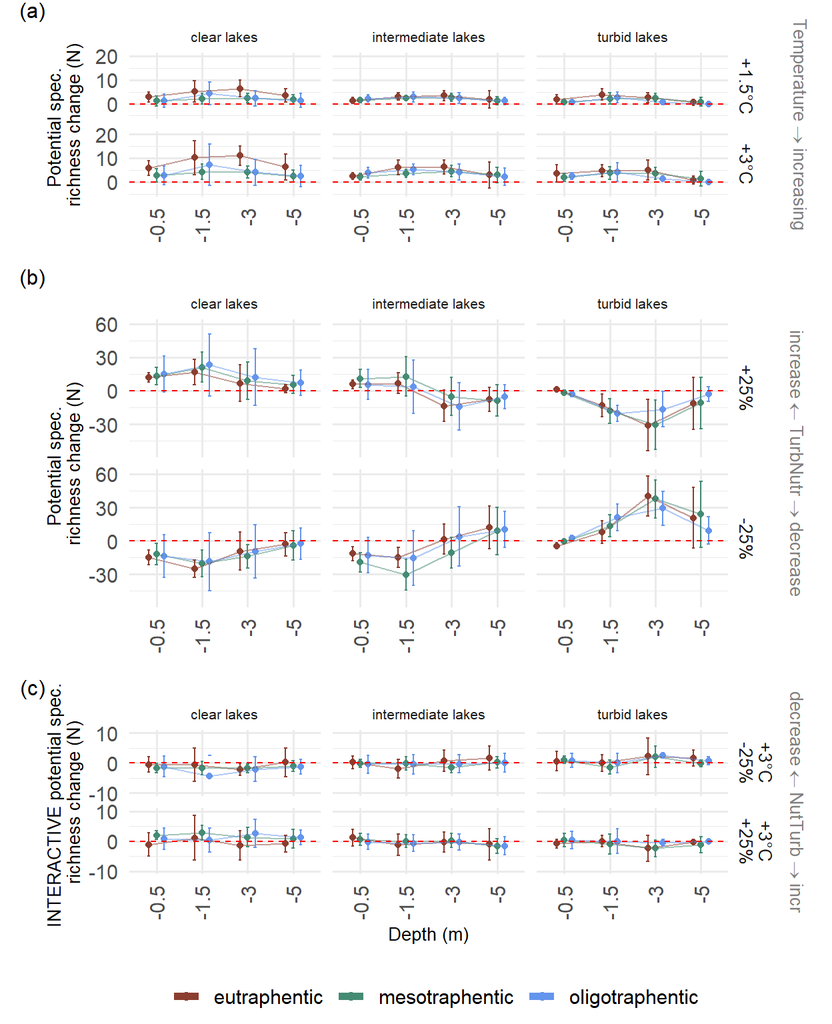

```r
#COMBINE PLOTS
FIG3fin<-((Fig3A + xlab(""))/
   (Fig3B + xlab("")) /
   (Fig3C )) +
  plot_annotation(tag_levels = 'a',
                  tag_prefix = '(',
                  tag_suffix = ')')+
  #labs(col="Spec. group") +
  plot_layout(heights = c(1, 2, 1)) +
  plot_layout(guides = "collect") &
  theme(legend.position = "bottom",
        strip.text.x = element_text(size = 8),
                strip.text.y = element_text(size = 10),
                axis.text.x = element_text(angle = 90,
                                           vjust = 0.5, hjust=1),
                axis.title=element_text(size=10))&
  theme(plot.margin =  unit(c(-0.0, 0.2, -0.0, 0.2), "cm"),
        plot.tag = element_text(size = 12))&
  guides(colour = guide_legend(override.aes = list(size=2)))

FIG3fin
```

```r
# ggsave("Fig3.png", FIG3fin, width = 6.5, height=8, dpi="print", bg="white")
```

#### 2.3.2.4 Win and Lost of species

Alte Analyse, die cih hier mal lasse, weil sie nett ist.

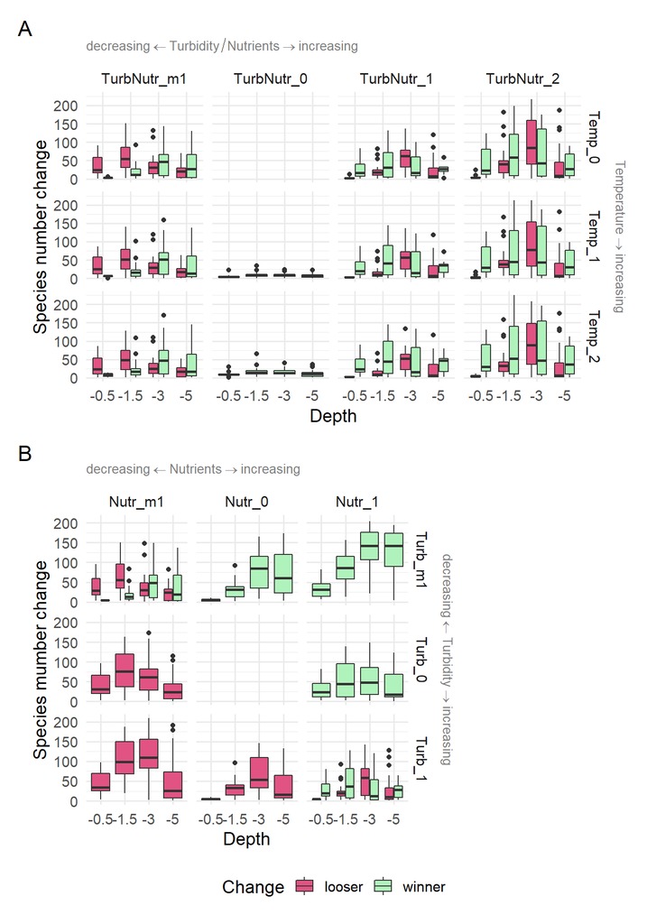

```r
scen.labs <- c("S0_m1", "base"," S0_1", "SO_2", "S1_m1", "S1_0", "S1_1","S1_2", "S2_m1 *",
               "S2_0", "S2_1 *","S2_2")

scen.labs.Turb <- c("TurbNutr_m1","TurbNutr_0","TurbNutr_1","TurbNutr_2")
names(scen.labs.Turb)<- c("TurbNutr_m1","TurbNutr_0","TurbNutr_1","TurbNutr_2")

names(scen.labs) <- c("S0_m1minusBase", "base","S0_1minusBase", "S0_2minusBase",
                      "S1_m1minusBase", "S1_0minusBase", "S1_1minusBase", "S1_2minusBase",
                      "S2_m1minusBase", "S2_0minusBase", "S2_1minusBase", "S2_2minusBase")
presabs.labs <- c("Loss", "Increase")
names(presabs.labs) <- c("-1", "1")

scen2.labs <- c("S2_m1 *", "S2_N0_Tm1"," S2_N1_Tm1",
                "S2_Nm1_T0", "S2_0", "S2_N1_T0",
                "S2_Nm1_T1","S2_N0_T1", "S2_1 *")
names(scen2.labs) <- c("S2_m1minusS2_0",
      "S2_N0_Tm1minusS2_0",
      "S2_N1_Tm1minusS2_0",
      "S2_Nm1_T0minusS2_0",
      "S2_0",
      "S2_N1_T0minusS2_0",
      "S2_Nm1_T1minusS2_0",
      "S2_N0_T1minusS2_0",
      "S2_1minusS2_0")

annotate_background <- tibble(
  scenario = scen.labs,
  color = "blue",
  variable = -2
)


Nspec_base_perdepth <-all_diff_presabs_tobase %>%
  group_by(lakeID, variable) %>%
  summarise(
    base = sum(base),
    S0_m1 = sum(S0_m1),
    S0_1 = sum(S0_1),
    S0_2 = sum(S0_2),
    S1_m1 = sum(S1_m1),
    S1_0 = sum(S1_0),
    S1_1 = sum(S1_1),
    S1_2 = sum(S1_2),
    S2_m1 = sum(S2_m1),
    S2_0 = sum(S2_0),
    S2_1 = sum(S2_1),
    S2_2 = sum(S2_2)
  ) %>% select(lakeID, variable, base)


#IDEE: add line with mean change per depth and in total

FigAll<-all_diff_presabs_tobase %>% # filter(S1minusBase!=0)%>%filter(S2minusBase!=0)%>%
  gather("scenario", "PreAbsChange", c(16:32)) %>% # 4,
  group_by(lakeID, variable, scenario) %>%
  count(PreAbsChange) %>%
  filter(PreAbsChange != 0) %>%
  left_join(Nspec_base_perdepth, by=c("lakeID"="lakeID","variable"="variable")) %>%
  ungroup() %>%
  mutate(nPerc = (n/base)*100) %>%
  add_row(scenario = "base", variable = c(-5.0)) %>%

  mutate(scenarioTemp =
           ifelse(scenario=="S0_m1minusBase" |
                    scenario=="S0_1minusBase" |
                    scenario=="S0_2minusBase" | scenario=="base","Temp_0",
           ifelse(scenario=="S1_m1minusBase" | scenario=="S1_1minusBase" |
                    scenario=="S1_2minusBase" | scenario=="S1_0minusBase","Temp_1",
            ifelse(scenario=="S2_m1minusBase" | scenario=="S2_1minusBase" |
                     scenario=="S2_2minusBase" | scenario=="S2_0minusBase",
                   "Temp_2","others"))
                                )) %>%
    mutate(scenarioTurbNut =
           ifelse(scenario=="S0_m1minusBase" |
                    scenario=="S1_m1minusBase" |
                    scenario=="S2_m1minusBase" ,"TurbNutr_m1",
           ifelse(scenario=="base" | scenario=="S1_0minusBase" |
                    scenario=="S2_0minusBase" ,"TurbNutr_0",
            ifelse(scenario=="S0_1minusBase" | scenario=="S1_1minusBase" |
                     scenario=="S2_1minusBase" ,
                   "TurbNutr_1",
                   ifelse(scenario=="S0_2minusBase" | scenario=="S1_2minusBase" |
                     scenario=="S2_2minusBase" ,
                   "TurbNutr_2","others"))
                                ))) %>%
    transform(scenarioTurbNut = factor(
    scenarioTurbNut,
    levels = c(
      "TurbNutr_m1",
      "TurbNutr_0",
      "TurbNutr_1",
      "TurbNutr_2"
    )
  )) %>%

  filter(scenarioTemp!="NA") %>%
  filter(scenarioTurbNut!="NA") %>%
  ggplot(aes(
    x = factor(variable),
    y = n,
    fill = factor(PreAbsChange)
  )) +
  facet_grid( scenarioTemp~scenarioTurbNut,
              labeller = labeller(scenarioTurbNut = scen.labs.Turb)
              #nrow = 3
              ) +
  geom_boxplot(aes()) +
  ylab("species")+
  scale_x_discrete(limits = rev) +
  guides(fill = guide_legend(title = "Change")) +
  scale_fill_manual(labels = c("looser", "winner"), #,"others","TempEffect","TurbNutrEffect"
                    values = (WinnerLoserPalette))+ #,"white","mistyrose","cornsilk"
  ggtitle(expression(decreasing %<-% Turbidity/Nutrients %->% increasing))+
  theme(plot.title = element_text(size = 10,color = "grey50"))+
  theme(legend.position = "bottom")+
  scale_y_continuous(
    sec.axis = dup_axis(name = expression(Temperature %->% increasing), breaks = NULL))+
  theme(axis.title.y.right = element_text(size=10,color = "grey50"))+
  xlab("Depth") +
  ylab("Species number change")


FigTurbNutr <- scenTurbNutr_diff_presabs_toZero %>%
    gather("scenario", "PreAbsChange", c(13:29)) %>% # 4,
  group_by(lakeID, variable, scenario) %>%
  count(PreAbsChange) %>%
  filter(PreAbsChange != 0)%>%
  ungroup() %>%
  add_row(scenario = "S2_0", variable = c(-5.0)) %>%
  #add_row(scenario = "blank1", variable = c(-5.0)) %>%
  #add_row(scenario = "blank2", variable = c(-5.0)) %>%
  #add_row(scenario = "blank3", variable = c(-5.0)) %>%

  mutate(scenarioTurb =
           ifelse(scenario=="S2_Nm1_T0minusS2_0" | scenario=="S2_0" |
                    scenario=="S2_N1_T0minusS2_0","Turb_0",
                         ifelse(scenario=="S2_m1minusS2_0" | scenario=="S2_N0_Tm1minusS2_0" |
                                  scenario=="S2_N1_Tm1minusS2_0","Turb_m1",
                                ifelse(scenario=="S2_Nm1_T1minusS2_0" |
                                         scenario=="S2_N0_T1minusS2_0" |
                                         scenario=="S2_1minusS2_0","Turb_1","others"))
                                )) %>%
    transform(scenarioTurb = factor(
  scenarioTurb,
    levels = c(
      "Turb_m1", "Turb_0","Turb_1"
      )
  ))  %>%
    mutate(scenarioNutr =
           ifelse(scenario=="S2_m1minusS2_0" | scenario=="S2_Nm1_T0minusS2_0" |
                    scenario=="S2_Nm1_T1minusS2_0","Nutr_m1",
                         ifelse(scenario=="S2_N0_Tm1minusS2_0" | scenario=="S2_0" |
                                  scenario=="S2_N0_T1minusS2_0","Nutr_0",
                                ifelse(scenario=="S2_N1_Tm1minusS2_0" |
                                         scenario=="S2_N1_T0minusS2_0" |
                                         scenario=="S2_1minusS2_0","Nutr_1","others"))
                                )) %>%
  transform(scenarioNutr = factor(
  scenarioNutr,
    levels = c(
      "Nutr_m1", "Nutr_0","Nutr_1"
      )
  ))  %>%
  filter(scenarioNutr!="NA") %>%
  filter(scenarioTurb!="NA") %>%
  ggplot(aes(x = factor(variable), y = n, fill = factor(PreAbsChange))) +
  geom_boxplot(aes()) +
  ylab("species") +
  facet_grid(scenarioTurb~scenarioNutr #, nrow = 3,labeller = labeller(scenario = scen2.labs)
             ) +
  scale_x_discrete(limits = rev) +
  xlab("Depth") +
  ylab("Species mumber change") + ylim(0,40) +
  guides(fill = guide_legend(title = "Change")) +
  scale_y_continuous(
    sec.axis = dup_axis(name = expression(decreasing %<-% Turbidity %->% increasing),
                        breaks = NULL))+
  theme(axis.title.y.right = element_text(size=10,color = "grey50"))+
    ggtitle(expression(decreasing %<-% Nutrients %->% increasing))+
  theme(plot.title = element_text(size = 10,color = "grey50"))+
  scale_fill_manual(labels = c("looser", "winner"),
                               values = (WinnerLoserPalette))+
  theme(legend.position = "bottom")


FIG3<-FigAll / (FigTurbNutr+plot_spacer()+
  plot_layout(widths = c(3, 1)))  & theme(legend.position = "bottom")
FIG3+
  plot_annotation(tag_levels = 'A') +
  plot_layout(guides = "collect")
```

## 2.4 Q3 - Traits Winner / Loser

### 2.4.1 S2_m1 and S2_1

```r
# WinnerLoserTraitsS2_1_S2_m1_all<-all_diff_presabs_tobase %>%
#   #mutate(Trophie = ifelse(speciesID %in% c(14001:14300), "oligo",
#   #                        ifelse(speciesID %in% c(15001:15300), "meso",
#   #                               ifelse(speciesID %in% c(16001:16300), "eu",NA)))) %>%
#   select(speciesID,lakeID, variable,base,
#          S2_1,S2_m1) %>%
#   group_by(speciesID, lakeID) %>% #to make it independent from depth
#   summarise(S2_1=sum(S2_1),
#             S2_m1=sum(S2_m1),
#             base=sum(base)) %>%
#   mutate(S2_1=ifelse(S2_1>0,1,0),
#          S2_m1=ifelse(S2_m1>0,1,0),
#          base=ifelse(base>0,1,0)) %>%
#   mutate(S2_1minusBase=S2_1 - base,
#          S2_m1minusBase=S2_m1 - base) %>%
#   ungroup() %>%
#
#   group_by(speciesID) %>%
#   summarise(lakeWinLostS2_1 = sum(S2_1minusBase),
#             lakeWinLostS2_m1 = sum(S2_m1minusBase)) %>%
#     mutate(lakeWinLostS2_1=ifelse(lakeWinLostS2_1>0,1,
#                             ifelse(lakeWinLostS2_1<0,-1,0)),
#            lakeWinLostS2_m1=ifelse(lakeWinLostS2_m1>0,1,
#                             ifelse(lakeWinLostS2_m1<0,-1,0))) %>%
#   left_join(data_spec_para, by=c("speciesID"="specNr")) %>%
#   #gather("parameter","value",c(5,7:24)) %>%
#   select(-tuberEndAge, -Group)%>%
#   gather("Scenario","WinLost",2:3)
#
#
# data.glmS2_1  <- WinnerLoserTraitsS2_1_S2_m1_all %>%
#   filter(Scenario=="lakeWinLostS2_1") %>%
#   filter(WinLost!=0) %>%
#   mutate(WinLost=factor(WinLost)) %>%
#   select(-speciesID,-Scenario) %>%
#   #spread(parameter,value)%>%
#   ungroup() %>%
#   as.data.frame() %>%
#   mutate_at(vars(-Species,-WinLost), normalize, method="range",range = c(0, 1))
#
# modSpaceS2_1 <- glm(formula = factor(WinLost)~ . ,data=data.glmS2_1[,-c(1)], family = binomial())
#
# #summary(modSpaceS2_1)
# glmSpace2_1 <- drop1(modSpaceS2_1, test="Chisq")
#
# #glmSpace2_1
#
# #tab_model(modSpace)
#
# T2_1<-plot_model(modSpaceS2_1, show.values = TRUE,
#            value.offset = .3, digits=1,sort.est = F,
#            title = "S2_1: Losers - Winners",
#            rm.terms = c("germinationDay", "heightMax", "hPhotoTemp","maxAge","pPhotoTemp",
#                         "rootShootRatio","seedBiomass","seedsEndAge","seedsStartAge")) #,
#
# # other szenario
# data.glmS2_m1  <- WinnerLoserTraitsS2_1_S2_m1_all %>%
#   filter(Scenario=="lakeWinLostS2_m1") %>%
#   filter(WinLost!=0) %>%
#   mutate(WinLost=factor(WinLost)) %>%
#   select(-speciesID,-Scenario) %>%
#   #spread(parameter,value)%>%
#   ungroup() %>%
#   as.data.frame() %>%
#   mutate_at(vars(-Species,-WinLost), normalize, method="range",range = c(0, 1))
#
# modSpaceS2_m1 <- glm(formula = factor(WinLost)~ . ,data=data.glmS2_m1[,-c(1)], family = binomial())
#
# #summary(modSpaceS2_m1)
# glmSpace2_m1 <- drop1(modSpaceS2_m1, test="Chisq")
#
# #glmSpace2_m1
#
# #tab_model(modSpace)
#
# T2_m1<-plot_model(modSpaceS2_m1, show.values = TRUE,
#            value.offset = .3, digits=1,sort.est = F,
#            title = "Traits of Losers - Winners",
#            rm.terms = c("germinationDay", "heightMax", "hPhotoTemp","maxAge","pPhotoTemp",
#                         "rootShootRatio","seedBiomass","seedsEndAge","seedsStartAge")) #,
#
# (T2_m1+
#     labs(subtitle = "A - S2_m1")) + (T2_1+
#   theme(axis.title.y=element_blank(),
#         axis.text.y=element_blank(),
#         axis.ticks.y=element_blank())+
#     labs(subtitle = "B - S2_1", title="")) #+ plot_annotation(tag_levels = 'A')
```

### 2.4.2 S0_m1 and S0_1

#### 2.4.2.1 ALL (FIG4)

```r
WinnerLoserTraitsS0_1_S0_m1_all<-all_diff_presabs_tobase %>%
  #filter(variable=="-3" | variable=="-5")%>%
  select(speciesID,lakeID, variable,base, S0_1,S0_m1) %>%
  group_by(speciesID, lakeID) %>% #to make it independent from depth
  summarise(S0_1=sum(S0_1),
            S0_m1=sum(S0_m1),
            base=sum(base)) %>%
  mutate(S0_1=ifelse(S0_1>0,1,0),
         S0_m1=ifelse(S0_m1>0,1,0),
         base=ifelse(base>0,1,0)) %>%
  mutate(S0_1minusBase=S0_1 - base,
         S0_m1minusBase=S0_m1 - base) %>%
  ungroup() %>%

  group_by(speciesID) %>%
  summarise(lakeWinLostS0_1 = sum(S0_1minusBase),
            lakeWinLostS0_m1 = sum(S0_m1minusBase)) %>%
  mutate(lakeWinLostS0_1=ifelse(lakeWinLostS0_1>0,1,
                            ifelse(lakeWinLostS0_1<0,-1,0)),
           lakeWinLostS0_m1=ifelse(lakeWinLostS0_m1>0,1,
                            ifelse(lakeWinLostS0_m1<0,-1,0))) %>%
  left_join(data_spec_para, by=c("speciesID"="specNr")) %>%
  select(-tuberEndAge, -Group)%>%
  gather("Scenario","WinLost",2:3)


data.glmS0_1  <- WinnerLoserTraitsS0_1_S0_m1_all %>%
  filter(Scenario=="lakeWinLostS0_1") %>%
  filter(WinLost!=0) %>%
  mutate(WinLost=factor(WinLost)) %>%
  select(-speciesID,-Scenario) %>%
  ungroup() %>%
  as.data.frame() %>%
  mutate_at(vars(-Species,-WinLost), normalize, method="range",range = c(0, 1))

modSpaceS0_1 <- glm(formula = factor(WinLost)~ . ,data=data.glmS0_1[,-c(1)], family = binomial())

summary(modSpaceS0_1)
```

```
##
## Call:
## glm(formula = factor(WinLost) ~ ., family = binomial(), data = data.glmS0_1[,
##     -c(1)])
##
## Deviance Residuals:
##      Min        1Q    Median        3Q       Max
## -2.65084   0.04143   0.19174   0.46016   2.05148
##
## Coefficients:
##                   Estimate Std. Error z value Pr(>|z|)
## (Intercept)       -0.62089    1.67239  -0.371 0.710447
## germinationDay    -1.35908    0.65990  -2.060 0.039445 *
## heightMax          1.16411    1.25214   0.930 0.352529
## hNutrient          0.85231    0.89126   0.956 0.338925
## hPhotoLight       -2.91213    0.79522  -3.662 0.000250 ***
## hPhotoTemp         0.11100    0.79768   0.139 0.889331
## hWaveMort         -5.58264    0.80136  -6.966 3.25e-12 ***
## maxAge            -3.14570    1.23164  -2.554 0.010647 *
## maxWaveMort       -0.81904    0.56404  -1.452 0.146474
## maxWeightLenRatio  1.37741    0.92995   1.481 0.138562
## pMax               9.71950    1.50546   6.456 1.07e-10 ***
## pNutrient          1.35618    1.05520   1.285 0.198707
## pPhotoTemp        -0.04469    0.59390  -0.075 0.940015
## pWaveMort          5.89895    0.85305   6.915 4.68e-12 ***
## reproDay           4.23288    1.21324   3.489 0.000485 ***
## rootShootRatio    -0.53753    1.02360  -0.525 0.599488
## seedBiomass       -2.26606    1.15139  -1.968 0.049056 *
## seedsEndAge        1.87118    0.86715   2.158 0.030938 *
## seedsStartAge     -0.40315    0.72779  -0.554 0.579627
## ---
## Signif. codes:  0 '***' 0.001 '**' 0.01 '*' 0.05 '.' 0.1 ' ' 1
##
## (Dispersion parameter for binomial family taken to be 1)
##
##     Null deviance: 411.03  on 417  degrees of freedom
## Residual deviance: 247.67  on 399  degrees of freedom
## AIC: 285.67
##
## Number of Fisher Scoring iterations: 6
```

```r
glmSpace0_1 <- drop1(modSpaceS0_1, test="Chisq")

glmSpace0_1
```

```
## Single term deletions
##
## Model:
## factor(WinLost) ~ germinationDay + heightMax + hNutrient + hPhotoLight +
##     hPhotoTemp + hWaveMort + maxAge + maxWaveMort + maxWeightLenRatio +
##     pMax + pNutrient + pPhotoTemp + pWaveMort + reproDay + rootShootRatio +
##     seedBiomass + seedsEndAge + seedsStartAge
##                   Df Deviance    AIC    LRT  Pr(>Chi)
## <none>                 247.67 285.67
## germinationDay     1   252.07 288.07  4.406 0.0358110 *
## heightMax          1   248.53 284.53  0.864 0.3526322
## hNutrient          1   248.60 284.60  0.931 0.3345968
## hPhotoLight        1   262.34 298.34 14.675 0.0001277 ***
## hPhotoTemp         1   247.69 283.69  0.019 0.8892602
## hWaveMort          1   320.48 356.48 72.819 < 2.2e-16 ***
## maxAge             1   254.65 290.65  6.986 0.0082145 **
## maxWaveMort        1   249.81 285.81  2.146 0.1429474
## maxWeightLenRatio  1   249.93 285.93  2.265 0.1323469
## pMax               1   311.51 347.51 63.845 1.346e-15 ***
## pNutrient          1   249.34 285.34  1.670 0.1962837
## pPhotoTemp         1   247.67 283.67  0.006 0.9400166
## pWaveMort          1   322.83 358.83 75.169 < 2.2e-16 ***
## reproDay           1   260.61 296.61 12.942 0.0003214 ***
## rootShootRatio     1   247.94 283.94  0.278 0.5983353
## seedBiomass        1   251.82 287.82  4.157 0.0414527 *
## seedsEndAge        1   252.49 288.49  4.821 0.0281228 *
## seedsStartAge      1   247.98 283.98  0.309 0.5780462
## ---
## Signif. codes:  0 '***' 0.001 '**' 0.01 '*' 0.05 '.' 0.1 ' ' 1
```

```r
# other szenario S0_m1
data.glmS0_m1  <- WinnerLoserTraitsS0_1_S0_m1_all %>%
  filter(Scenario=="lakeWinLostS0_m1") %>%
  filter(WinLost!=0) %>%
  mutate(WinLost=factor(WinLost)) %>%
  select(-speciesID,-Scenario) %>%
  #spread(parameter,value)%>%
  ungroup() %>%
  as.data.frame() %>%
  mutate_at(vars(-Species,-WinLost), normalize, method="range",range = c(0, 1))

modSpaceS0_m1 <- glm(formula = factor(WinLost)~ . ,
                     data=data.glmS0_m1[,-c(1)], family = binomial())


summary(modSpaceS0_m1)
```

```
##
## Call:
## glm(formula = factor(WinLost) ~ ., family = binomial(), data = data.glmS0_m1[,
##     -c(1)])
##
## Deviance Residuals:
##      Min        1Q    Median        3Q       Max
## -1.64780  -0.35692  -0.15508  -0.05165   2.85157
##
## Coefficients:
##                   Estimate Std. Error z value Pr(>|z|)
## (Intercept)       -1.04808    1.90735  -0.549 0.582665
## germinationDay     0.19586    0.69242   0.283 0.777286
## heightMax          0.59907    1.45071   0.413 0.679642
## hNutrient         -3.18774    1.19635  -2.665 0.007709 **
## hPhotoLight        3.34288    0.87592   3.816 0.000135 ***
## hPhotoTemp         0.07203    0.86558   0.083 0.933677
## hWaveMort          3.82258    0.74646   5.121 3.04e-07 ***
## maxAge             2.48164    1.34572   1.844 0.065168 .
## maxWaveMort        1.83863    0.62575   2.938 0.003300 **
## maxWeightLenRatio -2.64823    1.12863  -2.346 0.018955 *
## pMax              -7.63758    1.49951  -5.093 3.52e-07 ***
## pNutrient         -1.14718    1.13140  -1.014 0.310608
## pPhotoTemp         0.27919    0.67426   0.414 0.678823
## pWaveMort         -5.78449    0.91680  -6.309 2.80e-10 ***
## reproDay          -3.37029    1.23377  -2.732 0.006301 **
## rootShootRatio     1.56904    1.20763   1.299 0.193852
## seedBiomass        2.38469    1.25326   1.903 0.057069 .
## seedsEndAge       -0.73410    1.00034  -0.734 0.463039
## seedsStartAge     -0.90396    0.77978  -1.159 0.246355
## ---
## Signif. codes:  0 '***' 0.001 '**' 0.01 '*' 0.05 '.' 0.1 ' ' 1
##
## (Dispersion parameter for binomial family taken to be 1)
##
##     Null deviance: 349.60  on 478  degrees of freedom
## Residual deviance: 210.06  on 460  degrees of freedom
## AIC: 248.06
##
## Number of Fisher Scoring iterations: 7
```

```r
glmSpace0_m1 <- drop1(modSpaceS0_m1, test="Chisq")

glmSpace0_m1
```

```
## Single term deletions
##
## Model:
## factor(WinLost) ~ germinationDay + heightMax + hNutrient + hPhotoLight +
##     hPhotoTemp + hWaveMort + maxAge + maxWaveMort + maxWeightLenRatio +
##     pMax + pNutrient + pPhotoTemp + pWaveMort + reproDay + rootShootRatio +
##     seedBiomass + seedsEndAge + seedsStartAge
##                   Df Deviance    AIC    LRT  Pr(>Chi)
## <none>                 210.06 248.06
## germinationDay     1   210.13 246.13  0.080  0.777078
## heightMax          1   210.23 246.23  0.172  0.678746
## hNutrient          1   218.47 254.47  8.413  0.003725 **
## hPhotoLight        1   226.51 262.51 16.454 4.984e-05 ***
## hPhotoTemp         1   210.06 246.06  0.007  0.933683
## hWaveMort          1   241.84 277.84 31.787 1.720e-08 ***
## maxAge             1   213.63 249.63  3.576  0.058625 .
## maxWaveMort        1   219.25 255.25  9.194  0.002429 **
## maxWeightLenRatio  1   216.22 252.22  6.163  0.013048 *
## pMax               1   246.01 282.01 35.953 2.022e-09 ***
## pNutrient          1   211.09 247.09  1.038  0.308246
## pPhotoTemp         1   210.23 246.23  0.172  0.678552
## pWaveMort          1   272.01 308.01 61.958 3.508e-15 ***
## reproDay           1   217.62 253.62  7.559  0.005970 **
## rootShootRatio     1   211.80 247.80  1.746  0.186357
## seedBiomass        1   213.87 249.87  3.816  0.050769 .
## seedsEndAge        1   210.59 246.59  0.536  0.463929
## seedsStartAge      1   211.38 247.38  1.330  0.248871
## ---
## Signif. codes:  0 '***' 0.001 '**' 0.01 '*' 0.05 '.' 0.1 ' ' 1
```

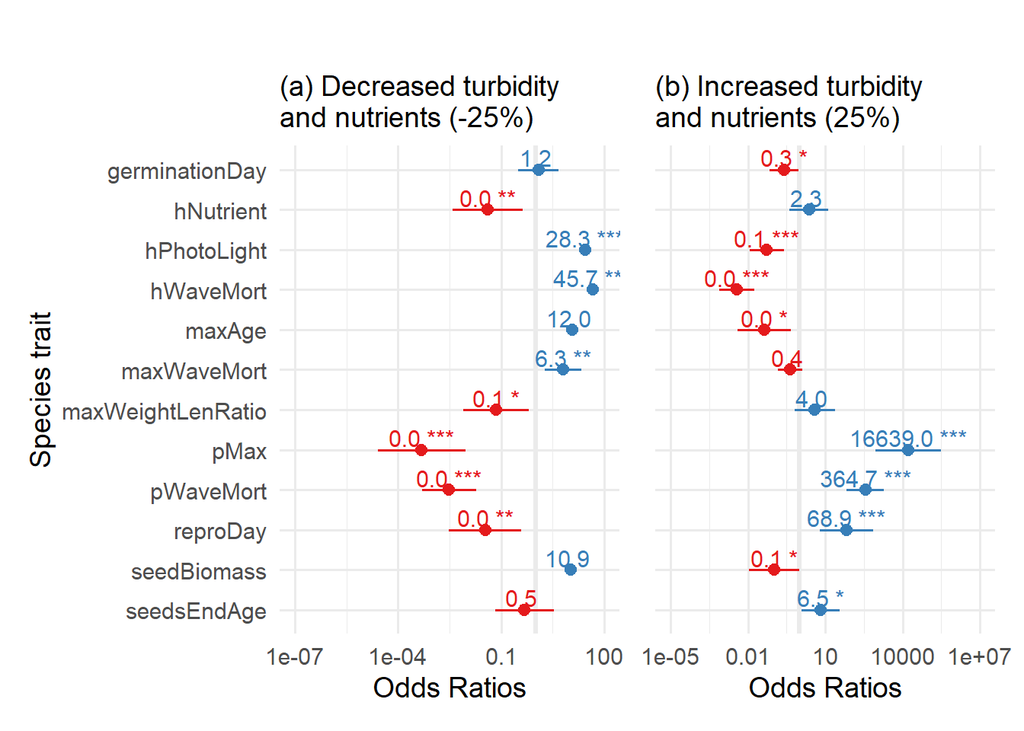

```r
#tab_model(modSpace)

## Select relevant (siginificant) parameters
toselect.S0_m1 <- summary(modSpaceS0_m1)$coeff[-1,4] < 0.05
relevant.S0_m1 <- names(toselect.S0_m1)[toselect.S0_m1 == TRUE]

toselect.S0_1 <- summary(modSpaceS0_1)$coeff[-1,4] < 0.05
relevant.S0_1 <- names(toselect.S0_1)[toselect.S0_1 == TRUE]

relevant <- c(relevant.S0_1,relevant.S0_m1) %>% unique()

T0_m1_all<-plot_model(modSpaceS0_m1, show.values = TRUE,
           value.offset = .3, digits=1,sort.est = F,
           title = "",
           terms=relevant) #,

T0_1_all<-plot_model(modSpaceS0_1, show.values = TRUE,
           value.offset = .3, digits=1,sort.est = F,
           #title = "S0_1: Losers - Winners",
           terms = relevant) #,


Fig4fin<-(T0_m1_all+
    labs(subtitle = "(a) Decreased turbidity \nand nutrients (-25%)") + labs(x="Species trait")) + (T0_1_all+
  theme(axis.title.y=element_blank(),
        axis.text.y=element_blank(),
        axis.ticks.y=element_blank())+
    labs(subtitle = "(b) Increased turbidity \nand nutrients (25%)", title="")) #+ plot_annotation(tag_levels = 'A')

Fig4fin
```

```r
#ggsave("Fig4.png", Fig4fin, width = 6.5, height=4, dpi="print", bg="white")
```

#### 2.4.2.2 S0_1

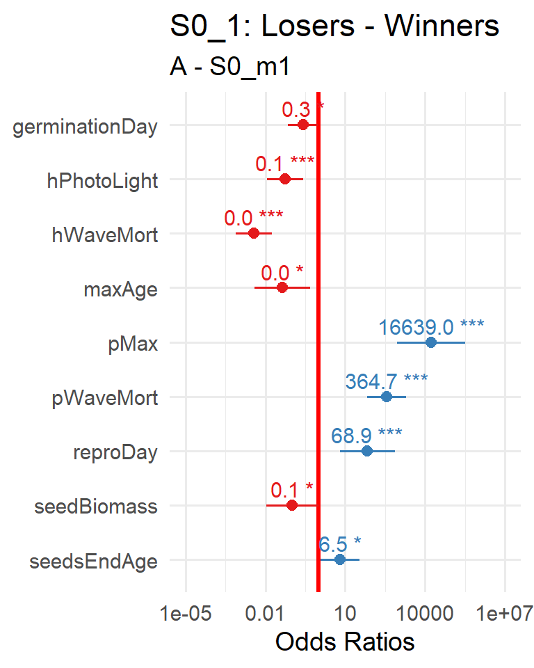

```r
data.glmS0_1  <- WinnerLoserTraitsS0_1_S0_m1_all %>%
  filter(Scenario=="lakeWinLostS0_1") %>%
  filter(WinLost!=0) %>%
  mutate(WinLost=factor(WinLost)) %>%
  select(-speciesID,-Scenario) %>%
  ungroup() %>%
  as.data.frame() %>%
  mutate_at(vars(-Species,-WinLost), normalize, method="range",range = c(0, 1))

modSpaceS0_1 <- glm(formula = factor(WinLost)~ . ,data=data.glmS0_1[,-c(1)], family = binomial())
toselect.S0_1 <- summary(modSpaceS0_1)$coeff[-1,4] < 0.05
relevant.S0_1 <- names(toselect.S0_1)[toselect.S0_1 == TRUE]

relevant <- c(relevant.S0_1) %>% unique()



T0_1_all<-plot_model(modSpaceS0_1, show.values = TRUE,
           value.offset = .3, digits=1,sort.est = F,
           title = "S0_1: Losers - Winners",
           terms = relevant, vline.color = "red") #,


(T0_1_all+
    labs(subtitle = "A - S0_m1")) #+ plot_annotation(tag_levels = 'A')
```

How good are the GLMs

```r
# with(summary(modSpaceS0_1), 1 - deviance/null.deviance)
# with(summary(modSpaceS0_m1), 1 - deviance/null.deviance)
#
#
# library(ResourceSelection)
# hoslem.test(modSpaceS0_1$y, modSpaceS0_1$fitted)
# hoslem.test(modSpaceS0_m1$y, modSpaceS0_m1$fitted)

#https://easystats.github.io/performance/articles/r2.html
performance::r2(modSpaceS0_1)
```

```
## # R2 for Logistic Regression
##   Tjur's R2: 0.404
```

```r
performance::r2(modSpaceS0_m1)
```

```
## # R2 for Logistic Regression
##   Tjur's R2: 0.364
```

In the context of a generalized linear model (e.g., a logistic model which outcome is binary), R2 doesn’t measure the percentage of “explained variance”, as this concept doesn’t apply. However, the R2s that have been adapted for GLMs have retained the name of “R2”, mostly because of the similar properties (the range, the sensitivity, and the interpretation as the amount of explanatory power).

Number of Winners / Loser in both scenarios

```r
NWinnerLoserS0_1<-data.glmS0_1 %>%
  count(WinLost) %>%
  mutate(S0_1_P=(n/NSPECbase*100))%>% select(-n)
NWinnerLoserS0_m1<- data.glmS0_m1 %>% count(WinLost)%>%
  mutate(S0_m1_P=(n/NSPECbase*100))%>% select(-n)

NWinnerLoserS0_1 %>% left_join(NWinnerLoserS0_m1, by="WinLost")
```

```
##   WinLost   S0_1_P  S0_m1_P
## 1      -1 15.00000 78.14815
## 2       1 62.40741 10.55556
```

#### 2.4.2.3 DEEP depth

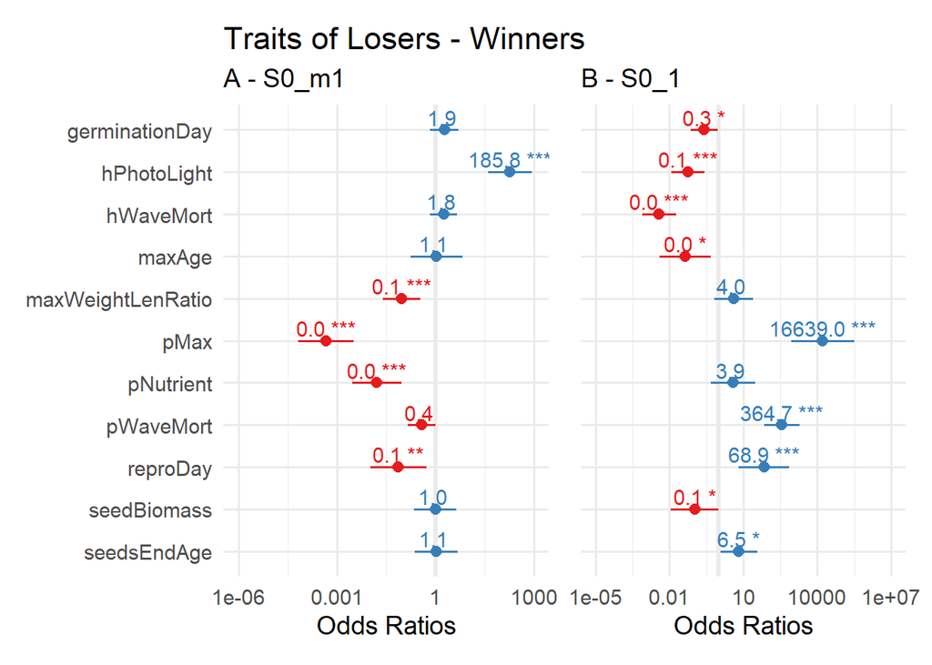

```r
WinnerLoserTraitsS0_1_S0_m1_dd<-all_diff_presabs_tobase %>%
  filter(variable=="-3" | variable=="-5")%>%
  select(speciesID,lakeID, variable,base, S0_1,S0_m1) %>%
  group_by(speciesID, lakeID) %>% #to make it independent from depth
  summarise(S0_1=sum(S0_1),
            S0_m1=sum(S0_m1),
            base=sum(base)) %>%
  mutate(S0_1=ifelse(S0_1>0,1,0),
         S0_m1=ifelse(S0_m1>0,1,0),
         base=ifelse(base>0,1,0)) %>%
  mutate(S0_1minusBase=S0_1 - base,
         S0_m1minusBase=S0_m1 - base) %>%
  ungroup() %>%

  group_by(speciesID) %>%
  summarise(lakeWinLostS0_1 = sum(S0_1minusBase),
            lakeWinLostS0_m1 = sum(S0_m1minusBase)) %>%
  mutate(lakeWinLostS0_1=ifelse(lakeWinLostS0_1>0,1,
                            ifelse(lakeWinLostS0_1<0,-1,0)),
           lakeWinLostS0_m1=ifelse(lakeWinLostS0_m1>0,1,
                            ifelse(lakeWinLostS0_m1<0,-1,0))) %>%
  left_join(data_spec_para, by=c("speciesID"="specNr")) %>%
  select(-tuberEndAge, -Group)%>%
  gather("Scenario","WinLost",2:3)


data.glmS0_1_deep  <- WinnerLoserTraitsS0_1_S0_m1_dd %>%
  filter(Scenario=="lakeWinLostS0_1") %>%
  filter(WinLost!=0) %>%
  mutate(WinLost=factor(WinLost)) %>%
  select(-speciesID,-Scenario) %>%
  ungroup() %>%
  as.data.frame() %>%
  mutate_at(vars(-Species,-WinLost), normalize, method="range",range = c(0, 1))

modSpaceS0_1_deep <- glm(formula = factor(WinLost)~ . ,data=data.glmS0_1_deep[,-c(1)], family = binomial())

#summary(modSpaceS2_1)
glmSpace0_1 <- drop1(modSpaceS0_1_deep, test="Chisq")

#glmSpace2_1

# other szenario
data.glmS0_m1_deep  <- WinnerLoserTraitsS0_1_S0_m1_dd %>%
  filter(Scenario=="lakeWinLostS0_m1") %>%
  filter(WinLost!=0) %>%
  mutate(WinLost=factor(WinLost)) %>%
  select(-speciesID,-Scenario) %>%
  #spread(parameter,value)%>%
  ungroup() %>%
  as.data.frame() %>%
  mutate_at(vars(-Species,-WinLost), normalize, method="range",range = c(0, 1))

modSpaceS0_m1 <- glm(formula = factor(WinLost)~ . ,
                     data=data.glmS0_m1_deep[,-c(1)], family = binomial())


#summary(modSpaceS2_m1)
glmSpace0_m1 <- drop1(modSpaceS0_m1, test="Chisq")

#glmSpace2_m1

#tab_model(modSpace)

## Select relevant (siginificant) parameters
toselect.S0_m1 <- summary(modSpaceS0_m1)$coeff[-1,4] < 0.05
relevant.S0_m1 <- names(toselect.S0_m1)[toselect.S0_m1 == TRUE]

toselect.S0_1 <- summary(modSpaceS0_1)$coeff[-1,4] < 0.05
relevant.S0_1 <- names(toselect.S0_1)[toselect.S0_1 == TRUE]

relevant <- c(relevant.S0_1,relevant.S0_m1) %>% unique()

T0_m1_d<-plot_model(modSpaceS0_m1, show.values = TRUE,
           value.offset = .3, digits=1,sort.est = F,
           title = "Traits of Losers - Winners",
           terms=relevant) #,

T0_1_d<-plot_model(modSpaceS0_1, show.values = TRUE,
           value.offset = .3, digits=1,sort.est = F,
           title = "S0_1: Losers - Winners",
           terms = relevant) #,


(T0_m1_d+
    labs(subtitle = "A - S0_m1")) + (T0_1_d+
  theme(axis.title.y=element_blank(),
        axis.text.y=element_blank(),
        axis.ticks.y=element_blank())+
    labs(subtitle = "B - S0_1", title="")) #+ plot_annotation(tag_levels = 'A')
```

#### 2.4.2.4 SHALLOW depth

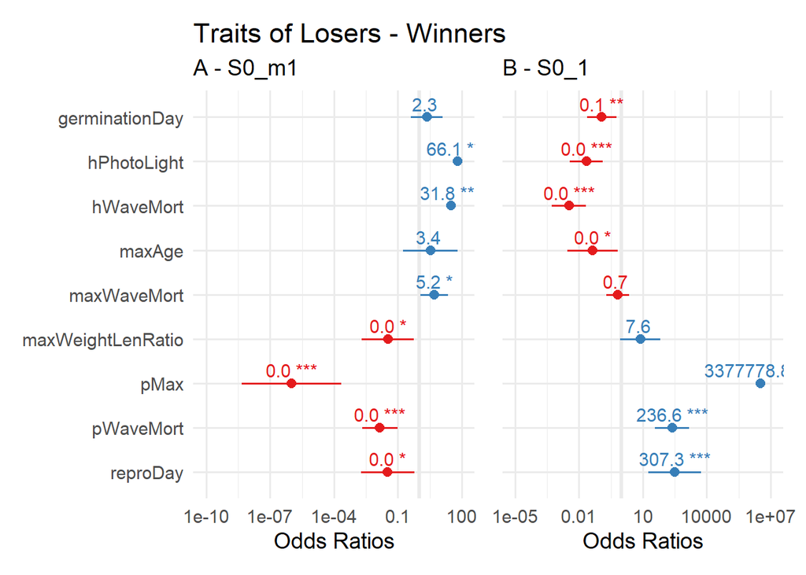

```r
WinnerLoserTraitsS0_1_S0_m1_ddd<-all_diff_presabs_tobase %>%
  filter(variable=="-1.5" | variable=="-0.5")%>%
  select(speciesID,lakeID, variable,base, S0_1,S0_m1) %>%
  group_by(speciesID, lakeID) %>% #to make it independent from depth
  summarise(S0_1=sum(S0_1),
            S0_m1=sum(S0_m1),
            base=sum(base)) %>%
  mutate(S0_1=ifelse(S0_1>0,1,0),
         S0_m1=ifelse(S0_m1>0,1,0),
         base=ifelse(base>0,1,0)) %>%
  mutate(S0_1minusBase=S0_1 - base,
         S0_m1minusBase=S0_m1 - base) %>%
  ungroup() %>%

  group_by(speciesID) %>%
  summarise(lakeWinLostS0_1 = sum(S0_1minusBase),
            lakeWinLostS0_m1 = sum(S0_m1minusBase)) %>%
  mutate(lakeWinLostS0_1=ifelse(lakeWinLostS0_1>0,1,
                            ifelse(lakeWinLostS0_1<0,-1,0)),
           lakeWinLostS0_m1=ifelse(lakeWinLostS0_m1>0,1,
                            ifelse(lakeWinLostS0_m1<0,-1,0))) %>%
  left_join(data_spec_para, by=c("speciesID"="specNr")) %>%
  select(-tuberEndAge, -Group)%>%
  gather("Scenario","WinLost",2:3)


data.glmS0_1_shallow  <- WinnerLoserTraitsS0_1_S0_m1_ddd %>%
  filter(Scenario=="lakeWinLostS0_1") %>%
  filter(WinLost!=0) %>%
  mutate(WinLost=factor(WinLost)) %>%
  select(-speciesID,-Scenario) %>%
  ungroup() %>%
  as.data.frame() %>%
  mutate_at(vars(-Species,-WinLost), normalize, method="range",range = c(0, 1))

modSpaceS0_1 <- glm(formula = factor(WinLost)~ . ,data=data.glmS0_1_shallow[,-c(1)], family = binomial())

#summary(modSpaceS2_1)
glmSpace0_1 <- drop1(modSpaceS0_1, test="Chisq")

#glmSpace2_1

#tab_model(modSpace)

# Will be ploted later
# T0_1<-plot_model(modSpaceS0_1, show.values = TRUE,
#            value.offset = .3, digits=1,sort.est = F,
#            title = "S0_1: Losers - Winners"#,
#            #rm.terms = c("germinationDay", "heightMax", "hPhotoTemp","maxAge","pPhotoTemp",
#           #              "rootShootRatio","seedBiomass","seedsEndAge","seedsStartAge")
#            ) #,

# other szenario
data.glmS0_m1_shallow  <- WinnerLoserTraitsS0_1_S0_m1_ddd %>%
  filter(Scenario=="lakeWinLostS0_m1") %>%
  filter(WinLost!=0) %>%
  mutate(WinLost=factor(WinLost)) %>%
  select(-speciesID,-Scenario) %>%
  #spread(parameter,value)%>%
  ungroup() %>%
  as.data.frame() %>%
  mutate_at(vars(-Species,-WinLost), normalize, method="range",range = c(0, 1))

modSpaceS0_m1 <- glm(formula = factor(WinLost)~ . ,
                     data=data.glmS0_m1_shallow[,-c(1)], family = binomial())


#summary(modSpaceS2_m1)
glmSpace0_m1 <- drop1(modSpaceS0_m1, test="Chisq")

#glmSpace2_m1

#tab_model(modSpace)

## Select relevant (siginificant) parameters
toselect.S0_m1 <- summary(modSpaceS0_m1)$coeff[-1,4] < 0.05
relevant.S0_m1 <- names(toselect.S0_m1)[toselect.S0_m1 == TRUE]

toselect.S0_1 <- summary(modSpaceS0_1)$coeff[-1,4] < 0.05
relevant.S0_1 <- names(toselect.S0_1)[toselect.S0_1 == TRUE]

relevant <- c(relevant.S0_1,relevant.S0_m1) %>% unique()

T0_m1_s<-plot_model(modSpaceS0_m1, show.values = TRUE,
           value.offset = .3, digits=1,sort.est = F,
           title = "Traits of Losers - Winners",
           terms=relevant) #,

T0_1_s<-plot_model(modSpaceS0_1, show.values = TRUE,
           value.offset = .3, digits=1,sort.est = F,
           title = "S0_1: Losers - Winners",
           terms = relevant) #,


(T0_m1_s+
    labs(subtitle = "A - S0_m1")) + (T0_1_s+
  theme(axis.title.y=element_blank(),
        axis.text.y=element_blank(),
        axis.ticks.y=element_blank())+
    labs(subtitle = "B - S0_1", title="")) #+ plot_annotation(tag_levels = 'A')
```

#### 2.4.2.5 Deep and Shallow and All

```r
# ((T0_m1_s+
#     labs(subtitle = "A - S0_m1 shallow")) +
#   (T0_1_s+
#   theme(axis.title.y=element_blank(),
#         axis.text.y=element_blank(),
#         axis.ticks.y=element_blank())+
#     labs(subtitle = "B - S0_1 shallow", title=""))) /
#   ((T0_m1_d+
#     labs(subtitle = "C - S0_m1 deep", title="")) + (T0_1_d+
#   theme(axis.title.y=element_blank(),
#         axis.text.y=element_blank(),
#         axis.ticks.y=element_blank()))+
#     labs(subtitle = "D - S0_1 deep", title=""))/
#   ((T0_m1_all+
#     labs(subtitle = "E - S0_m1 all depth", title="")) + (T0_1_all+
#   theme(axis.title.y=element_blank(),
#         axis.text.y=element_blank(),
#         axis.ticks.y=element_blank()))+
#     labs(subtitle = "F - S0_1 all depth", title=""))
```

#### 2.4.2.6 Winner/Loser

```r
# tw1<-data.glmS0_m1_deep %>% count(WinLost) %>%
#   mutate(S0_m1_deep_P=(n/NSPECbase*100))%>% select(-n)
#
# tw2<-data.glmS0_1_deep %>% count(WinLost) %>%
#   mutate(S0_1_deep_P=(n/NSPECbase*100))%>% select(-n)
#
# tw3<-data.glmS0_m1_shallow %>% count(WinLost) %>%
#   mutate(S0_m1_sha_P=(n/NSPECbase*100))%>% select(-n)
#
# tw4<-data.glmS0_1_shallow %>% count(WinLost) %>%
#   mutate(S0_1_sha_P=(n/NSPECbase*100))%>% select(-n)
#
# tw1 %>% left_join(tw2, by="WinLost")%>% left_join(tw3, by="WinLost")%>%
#   left_join(tw4, by="WinLost")
```

### 2.4.3 S2_0

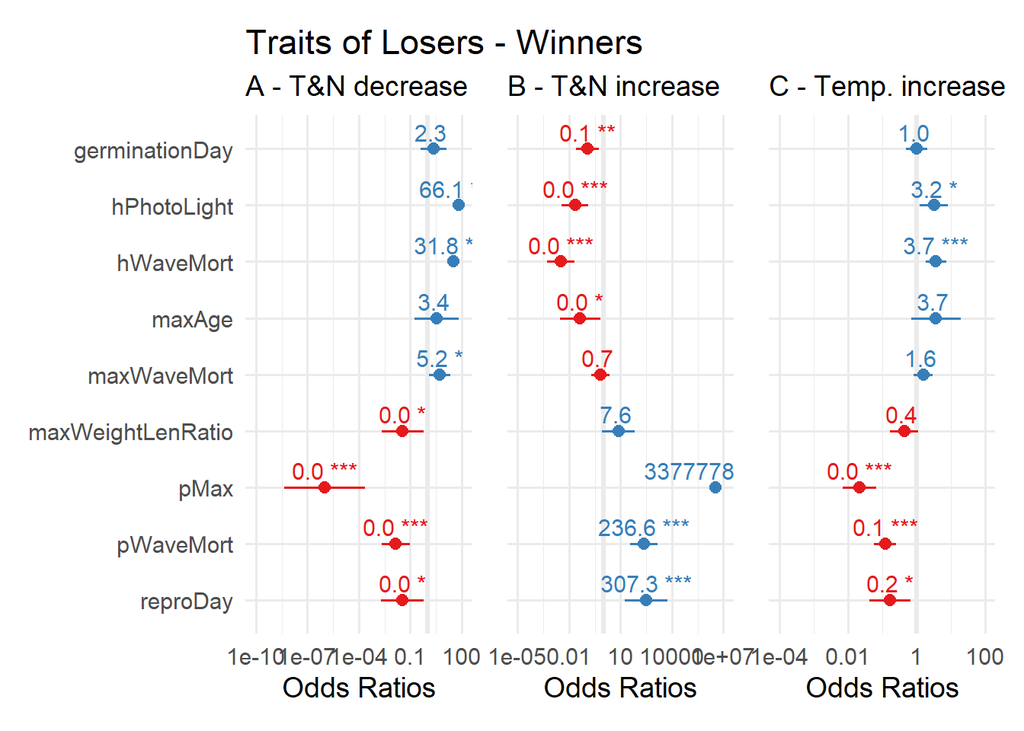

```r
WinnerLoserTraitsS2_0<-all_diff_presabs_tobase %>%
  #filter(variable=="-3" | variable=="-5")%>%
  select(speciesID,lakeID, variable,base, S2_0) %>%
  group_by(speciesID, lakeID) %>% #to make it independent from depth
  summarise(S2_0=sum(S2_0),
            base=sum(base)) %>%
  mutate(S2_0=ifelse(S2_0>0,1,0),
         base=ifelse(base>0,1,0)) %>%
  mutate(S2_0minusBase=S2_0 - base) %>%
  ungroup() %>%

  group_by(speciesID) %>%
  summarise(lakeWinLostS2_0 = sum(S2_0minusBase)) %>%
  mutate(lakeWinLostS2_0=ifelse(lakeWinLostS2_0>0,1,
                            ifelse(lakeWinLostS2_0<0,-1,0))) %>%
  left_join(data_spec_para, by=c("speciesID"="specNr")) %>%
  select(-tuberEndAge, -Group)


data.glmS2_0  <- WinnerLoserTraitsS2_0 %>%
  #filter(lakeWinLostS2_0!=0) %>%
  mutate(lakeWinLostS2_0=factor(lakeWinLostS2_0)) %>%
  select(-speciesID) %>%
  ungroup() %>%
  as.data.frame() %>%
  mutate_at(vars(-Species,-lakeWinLostS2_0), normalize, method="range",range = c(0, 1))

modSpaceS2_0 <- glm(formula = factor(lakeWinLostS2_0)~ . ,
                    data=data.glmS2_0[,-2], family = binomial())

#summary(modSpaceS2_0)
glmSpace2_0 <- drop1(modSpaceS2_0, test="Chisq")

#glmSpace2_0



## Select relevant (siginificant) parameters
toselect.S2_0 <- summary(modSpaceS2_0)$coeff[-1,4] < 0.05
relevant.S2_0 <- names(toselect.S2_0)[toselect.S2_0 == TRUE]

relevant <- c(relevant.S0_1,relevant.S0_m1,relevant.S0_m1) %>% unique()


T2_0_all<-plot_model(modSpaceS2_0, show.values = TRUE,
           value.offset = .3, digits=1,sort.est = F,
           title = "Traits of Losers - Winners",
           terms=relevant) #,

T0_m1_all<-plot_model(modSpaceS0_m1, show.values = TRUE,
           value.offset = .3, digits=1,sort.est = F,
           title = "Traits of Losers - Winners",
           terms=relevant) #,

T0_1_all<-plot_model(modSpaceS0_1, show.values = TRUE,
           value.offset = .3, digits=1,sort.est = F,
           title = "S0_1: Losers - Winners",
           terms = relevant) #,


(T0_m1_all+
    labs(subtitle = "A - T&N decrease")) + (T0_1_all+
  theme(axis.title.y=element_blank(),
        axis.text.y=element_blank(),
        axis.ticks.y=element_blank())+
    labs(subtitle = "B - T&N increase", title=""))+
  (T2_0_all+
  theme(axis.title.y=element_blank(),
        axis.text.y=element_blank(),
        axis.ticks.y=element_blank())+
    labs(subtitle = "C - Temp. increase", title=""))
```